# Capstone Project: Create a Customer Segmentation Report for Arvato Financial Services

In this project, you will analyze demographics data for customers of a mail-order sales company in Germany, comparing it against demographics information for the general population. You'll use unsupervised learning techniques to perform customer segmentation, identifying the parts of the population that best describe the core customer base of the company. Then, you'll apply what you've learned on a third dataset with demographics information for targets of a marketing campaign for the company, and use a model to predict which individuals are most likely to convert into becoming customers for the company. The data that you will use has been provided by our partners at Bertelsmann Arvato Analytics, and represents a real-life data science task.

If you completed the first term of this program, you will be familiar with the first part of this project, from the unsupervised learning project. The versions of those two datasets used in this project will include many more features and has not been pre-cleaned. You are also free to choose whatever approach you'd like to analyzing the data rather than follow pre-determined steps. In your work on this project, make sure that you carefully document your steps and decisions, since your main deliverable for this project will be a blog post reporting your findings.

```python
# import libraries here; add more as necessary
import numpy as np
import pandas as pd
import matplotlib.pyplot as plt
import seaborn as sns
from IPython.display import display
from datetime import datetime
import random
import pickle

from sklearn.cluster import KMeans
from sklearn.decomposition import PCA
from sklearn.ensemble import RandomForestClassifier, AdaBoostClassifier, GradientBoostingClassifier
from sklearn.feature_selection import SelectFromModel
from sklearn.impute import SimpleImputer
from sklearn.linear_model import LogisticRegression, LogisticRegressionCV # , Lasso
from sklearn.model_selection import train_test_split, GridSearchCV, cross_val_score #, RandomizedSearchCV
from sklearn.metrics import classification_report, roc_auc_score, roc_curve, confusion_matrix
from sklearn.preprocessing import RobustScaler, StandardScaler
from sklearn.tree import DecisionTreeClassifier
import xgboost as xgb # from xgboost import XGBClassifier, plot_importance
from bayes_opt import BayesianOptimization

# from sklearn.naive_bayes import GaussianNB, BernoulliNB, MultinomialNB
# import matplotlib.ticker as ticker
# from sklearn.pipeline import Pipeline
# from sklearn.svm import LinearSVC, SVC
import lightgbm as lgb

# Printing options (optional)
%matplotlib inline
pd.set_option('display.max_columns', None)
pd.set_option('display.max_rows', 30)
pd.set_option('display.max_colwidth', -1)
plt.rc("font", size = 14)
sns.set(style = "white")
sns.set(style = "whitegrid", color_codes = True)
import warnings
warnings.filterwarnings("ignore")
```

## Part 0: Get to Know the Data

Each row of the demographics files represents a single person, but also includes information outside of individuals, including information about their household, building, and neighborhood. **Use the information from the first two files to figure out how customers ("CUSTOMERS") are similar to or differ from the general population at large ("AZDIAS"), then use your analysis to make predictions on the other two files ("MAILOUT"), predicting which recipients are most likely to become a customer for the mail-order company**.

The "CUSTOMERS" file contains three extra columns ('CUSTOMER_GROUP', 'ONLINE_PURCHASE', and 'PRODUCT_GROUP'), which provide broad information about the customers depicted in the file. The original "MAILOUT" file included one additional column, "RESPONSE", which indicated whether or not each recipient became a customer of the company. For the "TRAIN" subset, this column has been retained, but in the "TEST" subset it has been removed; it is against that withheld column that your final predictions will be assessed in the Kaggle competition.

Otherwise, all of the remaining columns are the same between the three data files. For more information about the columns depicted in the files, you can refer to two Excel spreadsheets provided in the workspace. **One of them is a top-level list of attributes and descriptions, organized by informational category**. **The other is a detailed mapping of data values for each feature in alphabetical order**.

In the below cell, we've provided some initial code to load in the first two datasets. Note for all of the `.csv` data files in this project that they're semicolon (`;`) delimited, so an additional argument in the [`read_csv()`](https://pandas.pydata.org/pandas-docs/stable/generated/pandas.read_csv.html) call has been included to read in the data properly. Also, considering the size of the datasets, it may take some time for them to load completely.

You'll notice when the data is loaded in that a warning message will immediately pop up. Before you really start digging into the modeling and analysis, you're going to need to perform some cleaning. Take some time to browse the structure of the data and look over the informational spreadsheets to understand the data values. Make some decisions on which features to keep, which features to drop, and if any revisions need to be made on data formats. It'll be a good idea to create a function with pre-processing steps, since you'll need to clean all of the datasets before you work with them.

```python
# load in the data
path = '/Users/hyeukjung/Desktop/Udacity/Data Science Nanodegree Term 2/data/Term2/capstone/arvato_data/'
# '../../data/Term2/capstone/arvato_data/'
start = datetime.now()
azdias = pd.read_csv(path + 'Udacity_AZDIAS_052018.csv', sep = ';', low_memory = False)
customers = pd.read_csv(path + 'Udacity_CUSTOMERS_052018.csv', sep = ';', low_memory = False)
print( 'loading time: {}'.format(str(datetime.now() - start)) )
```

```
loading time: 0:00:46.535335
```

```python
dias_attributes = pd.read_excel(path + "DIAS Attributes - Values 2017.xlsx", header = 1)
dias_info = pd.read_excel(path + "DIAS Information Levels - Attributes 2017.xlsx", header = 1)
del dias_attributes['Unnamed: 0']
del dias_info['Unnamed: 0']

dias_attributes['Attribute'].fillna(method = 'ffill', inplace = True)
dias_attributes['Description'].fillna(method = 'ffill', inplace = True)
dias_attributes['Meaning'].fillna(method ='ffill', inplace = True)
dias_info['Information level'].fillna(method = 'ffill', inplace = True)
dias_info['Information level'].fillna(method = 'bfill', inplace = True)
```

```python
# # General
# display(azdias.head())
# display(azdias.info())

# # Customers
# display(customers.head())
# display(customers.info())
```

```python
# display(dias_attributes.head())
# display(dias_attributes.info())
# # dias_attributes[dias_attributes.isnull().any(axis = 1)]

# display(dias_info.head())
# display(dias_info.info())
```

# Preprocessing

### Step 1. Deal with Missing or Unknown Values

1. Check object type columns and transform to numeric type if applicable
2. For columns with specified unknown values, which are provided in the attribute dataset, unify all to NaN. For other columns in the dataset, change ['X', 'XX'] values to NaN

### Step 2. Drop Columns

Columns that do not pass the following conditions will be dropped:

1. Columns not described in the attribute or information files
2. Columns with missing values ( > 30%)
3. Correlation ( > 90%): For the future analysis, highly correlated columns should be dropped as these columns may cause errors in the classfication or regression methods.

### Step 3. Drop Rows

1. Except for the test set, drop rows which have missing values greater than 20%

### Step 4. Drop Extra Columns

After step 1~3, I found that `FINANZ_SPARER, KBA05_KRSHERST2, KBA05_SEG9, KBA05_KRSHERST3, D19_VERSAND_DATUM` do not overlap in the general population(`azdias` hereafter) and customers datasets (`customers` hereafter). Also, in `GEBAEUDETYP, TITEL_KZ` columns, number of unique values found in the two datasets were different. Therefore, I decided to additionally drop these columns.

```python
def plot_null_ratio(df, axis = 1):
    ''' plot the top 50 columns' null value ratio
    args:
    df; (dataframe) the dataframe you want to check the ratio

    return:
    missing_ratio; (dataframe) descending-ordered values
    '''
    # By column
    if axis == 1:
        null_ratio = df.isnull().sum() / df.shape[0]
        null_ratio.sort_values(ascending = False, inplace = True)

        plt.figure(figsize = (10, 6))
        null_ratio[:50].plot.bar()
        plt.title('Distribution of the Ratio of Missing Values in Each Column')
        plt.xlabel('Percentage of missing values')
        plt.ylabel('Count')
        plt.show()

    # By row
    elif axis == 0:
        null_ratio = df.isnull().sum(axis = 1) / df.shape[1]
        null_ratio.sort_values(ascending = False, inplace = True)

        plt.figure(figsize = (10, 6))
        null_ratio.plot.hist(bins = 50)
        plt.title('Distribution of the Ratio of Missing Values in Each Row')
        plt.xlabel('Percentage of missing values')
        plt.ylabel('Count')
        plt.show()

    return null_ratio
```

```python
def data_cleaning(df, col_to_keep = ['LNR'], test_set = False):
    ''' drop columns with missing values and highly-correlated columns
    args:
    df; (dataframe) the two main datasets used in this project

    return:
    df; (dataframe) cleaned datasets
    '''
    # 1.1) Change two object type columns to numeric type
    ## Only used azdias' columns as both datasets have the same columns
    ## CAMEO_INTL_2015, EINGEFUEGT_AM info unavailable in the attribute data
    print('1.1) Transform object to numeric-type columns')
    df_object_col = df.select_dtypes(include = ['object']).columns.tolist()
    print('[Before transforming]')
    for col in df_object_col:
        print(col, ':', df[col].unique())

    df.CAMEO_DEUG_2015.replace('X', np.nan, inplace = True)
    df.CAMEO_INTL_2015.replace('XX', np.nan, inplace = True)
    to_numeric_col = ['CAMEO_DEUG_2015', 'CAMEO_INTL_2015']
    df[to_numeric_col] = df[to_numeric_col].apply(pd.to_numeric)
    print('\n[After transforming]')
    for col in df_object_col:
        print(col, ':', df[col].unique())

    # 1.2) For columns with specified unknown values, unify all to NaN
    ## For other columns in the dataset, change three values below to NaN
    ## Not sure for [no transactions known, no transaction known] values
    print('\n1.2) Deal with unknown values')
    temp = dias_attributes[dias_attributes.Meaning.isin(['unknown', 'unknown / no main age detectable'])]
    for col in df.columns:
        unknown_val = temp[temp.Attribute == col].Value.tolist()
        if len(unknown_val) != 0:
            df[col].replace(unknown_val + ['X', 'XX'], np.nan, inplace = True)
        else:
            df[col].replace(['X', 'XX'], np.nan, inplace = True)

    # 2.1) Drop columns not covered in the attribute or information dataset
    print('\n2.1) Drop columns not covered in the attribute or information dataset')
    dias_attributes_name = set(dias_attributes.Attribute)
    in_df_only = sorted(set(df.columns) - dias_attributes_name - set(col_to_keep)) # set(['LNR']))
    df.drop(in_df_only, axis = 1, inplace = True)
    print('Columns dropped due non coverage in the description files: {} columns'.format(len(in_df_only)),
          in_df_only)

    # 2.2) Drop columns with missing values > 20% in both data sets
    ## Check missing value ratio of each column and plot top 50
    print('\n2.2) Drop columns with missing values greater than 30% in the dataset')
    df_null = plot_null_ratio(df, axis = 1)
    null_cols = list(df_null.index[df_null > 0.3])
    ## Drop columns
    df.drop(null_cols, axis = 1, inplace = True)
    print('Columns dropped due to missing values:', len(null_cols), null_cols)

    # 2.3) Drop highly correlated columns
    print('\n2.3) Drop highly correlated columns (corr > 90%)')
    df_corr = df.corr()
    plt.figure(figsize = (10, 10)); sns.heatmap(df_corr, cmap = "YlGnBu"); plt.show();
    ## Select upper triangle of correlation matrix
    df_corr_upper = df_corr.where(np.triu(np.ones(df_corr.shape), k = 1).astype(np.bool))
    ## Find index of feature columns with correlation greater than 0.9
    correlated_col = [column for column in df_corr_upper.columns if any(df_corr_upper[column] > 0.9)]
    ## Drop columns
    df.drop(correlated_col, axis = 1, inplace = True)
    print('Columns dropped due to high correlation:', len(correlated_col), correlated_col)

    if test_set == False:
        # 3.1) Drop rows with missing values greater than 20%
        print('\n3.1) Drop rows with missing values greater than 20%')
        df_null_row = plot_null_ratio(df, axis = 0)
        ## Drop rows
        df.drop(df_null_row[df_null_row > 0.2].index, axis = 0, inplace = True)
        print('Rows dropped from the dataset: {}'.format(len(df_null_row[df_null_row > 0.2])))
    else:
        print('TEST SET - Rows cannot be dropped.')

    # 4. After running general steps, remove the following columns
    ## First five columns are due to the non-overlapping results after general cleaning
    ## Last two columns are due to different number of unique values in the two datasets,
    ## azdias and customers
    extra_col = ['FINANZ_SPARER', 'KBA05_KRSHERST2', 'KBA05_SEG9',
                 'KBA05_KRSHERST3', 'D19_VERSAND_DATUM',
                 'GEBAEUDETYP', 'TITEL_KZ']
    del_col = [i for i in extra_col if i in df.columns]
    df.drop(del_col, axis = 1, inplace = True)
    print('\nExtra column(s) dropped:', del_col)
    print('Total {} columns dropped'.format(len(in_df_only) + len(null_cols) + len(correlated_col) + len(del_col)))

    return df
```

```
1.1) Transform object to numeric-type columns
[Before transforming]
CAMEO_DEU_2015 : [nan '8A' '4C' '2A' '6B' '8C' '4A' '2D' '1A' '1E' '9D' '5C' '8B' '7A' '5D'
 '9E' '9B' '1B' '3D' '4E' '4B' '3C' '5A' '7B' '9A' '6D' '6E' '2C' '7C'
 '9C' '7D' '5E' '1D' '8D' '6C' '6A' '5B' '4D' '3A' '2B' '7E' '3B' '6F'
 '5F' '1C' 'XX']
CAMEO_DEUG_2015 : [nan '8' '4' '2' '6' '1' '9' '5' '7' '3' 'X']
CAMEO_INTL_2015 : [nan '51' '24' '12' '43' '54' '22' '14' '13' '15' '33' '41' '34' '55' '25'
 '23' '31' '52' '35' '45' '44' '32' 'XX']
D19_LETZTER_KAUF_BRANCHE : [nan 'D19_UNBEKANNT' 'D19_SCHUHE' 'D19_ENERGIE' 'D19_KOSMETIK'
 'D19_VOLLSORTIMENT' 'D19_SONSTIGE' 'D19_BANKEN_GROSS'
 'D19_DROGERIEARTIKEL' 'D19_HANDWERK' 'D19_BUCH_CD' 'D19_VERSICHERUNGEN'
 'D19_VERSAND_REST' 'D19_TELKO_REST' 'D19_BANKEN_DIREKT' 'D19_BANKEN_REST'
 'D19_FREIZEIT' 'D19_LEBENSMITTEL' 'D19_HAUS_DEKO' 'D19_BEKLEIDUNG_REST'
 'D19_SAMMELARTIKEL' 'D19_TELKO_MOBILE' 'D19_REISEN' 'D19_BEKLEIDUNG_GEH'
 'D19_TECHNIK' 'D19_NAHRUNGSERGAENZUNG' 'D19_DIGIT_SERV' 'D19_LOTTO'
 'D19_RATGEBER' 'D19_TIERARTIKEL' 'D19_KINDERARTIKEL' 'D19_BIO_OEKO'
 'D19_WEIN_FEINKOST' 'D19_GARTEN' 'D19_BILDUNG' 'D19_BANKEN_LOKAL']
EINGEFUEGT_AM : [nan '1992-02-10 00:00:00' '1992-02-12 00:00:00' ... '2010-12-02 00:00:00'
 '2005-03-19 00:00:00' '2011-11-18 00:00:00']
OST_WEST_KZ : [nan 'W' 'O']

[After transforming]
CAMEO_DEU_2015 : [nan '8A' '4C' '2A' '6B' '8C' '4A' '2D' '1A' '1E' '9D' '5C' '8B' '7A' '5D'
 '9E' '9B' '1B' '3D' '4E' '4B' '3C' '5A' '7B' '9A' '6D' '6E' '2C' '7C'
 '9C' '7D' '5E' '1D' '8D' '6C' '6A' '5B' '4D' '3A' '2B' '7E' '3B' '6F'
 '5F' '1C' 'XX']
CAMEO_DEUG_2015 : [nan  8.  4.  2.  6.  1.  9.  5.  7.  3.]
CAMEO_INTL_2015 : [nan 51. 24. 12. 43. 54. 22. 14. 13. 15. 33. 41. 34. 55. 25. 23. 31. 52.
 35. 45. 44. 32.]
D19_LETZTER_KAUF_BRANCHE : [nan 'D19_UNBEKANNT' 'D19_SCHUHE' 'D19_ENERGIE' 'D19_KOSMETIK'
 'D19_VOLLSORTIMENT' 'D19_SONSTIGE' 'D19_BANKEN_GROSS'
 'D19_DROGERIEARTIKEL' 'D19_HANDWERK' 'D19_BUCH_CD' 'D19_VERSICHERUNGEN'
 'D19_VERSAND_REST' 'D19_TELKO_REST' 'D19_BANKEN_DIREKT' 'D19_BANKEN_REST'
 'D19_FREIZEIT' 'D19_LEBENSMITTEL' 'D19_HAUS_DEKO' 'D19_BEKLEIDUNG_REST'
 'D19_SAMMELARTIKEL' 'D19_TELKO_MOBILE' 'D19_REISEN' 'D19_BEKLEIDUNG_GEH'
 'D19_TECHNIK' 'D19_NAHRUNGSERGAENZUNG' 'D19_DIGIT_SERV' 'D19_LOTTO'
 'D19_RATGEBER' 'D19_TIERARTIKEL' 'D19_KINDERARTIKEL' 'D19_BIO_OEKO'
 'D19_WEIN_FEINKOST' 'D19_GARTEN' 'D19_BILDUNG' 'D19_BANKEN_LOKAL']
EINGEFUEGT_AM : [nan '1992-02-10 00:00:00' '1992-02-12 00:00:00' ... '2010-12-02 00:00:00'
 '2005-03-19 00:00:00' '2011-11-18 00:00:00']
OST_WEST_KZ : [nan 'W' 'O']

1.2) Deal with unknown values

2.1) Drop columns not covered in the attribute or information dataset
Columns dropped due non coverage in the description files: 93 columns ['AKT_DAT_KL', 'ALTERSKATEGORIE_FEIN', 'ALTER_KIND1', 'ALTER_KIND2', 'ALTER_KIND3', 'ALTER_KIND4', 'ANZ_KINDER', 'ANZ_STATISTISCHE_HAUSHALTE', 'ARBEIT', 'CAMEO_INTL_2015', 'CJT_KATALOGNUTZER', 'CJT_TYP_1', 'CJT_TYP_2', 'CJT_TYP_3'…

2.2) Drop columns with missing values greater than 30% in the dataset
```

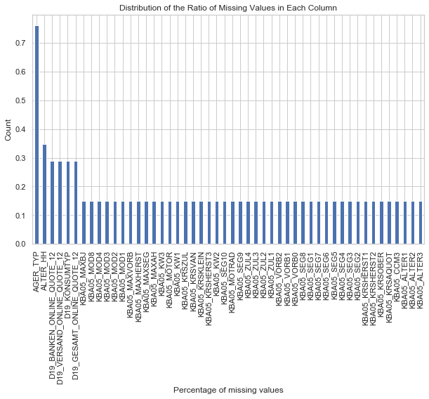

```
Columns dropped due to missing values: 2 ['AGER_TYP', 'ALTER_HH']

2.3) Drop highly correlated columns (corr > 90%)
```

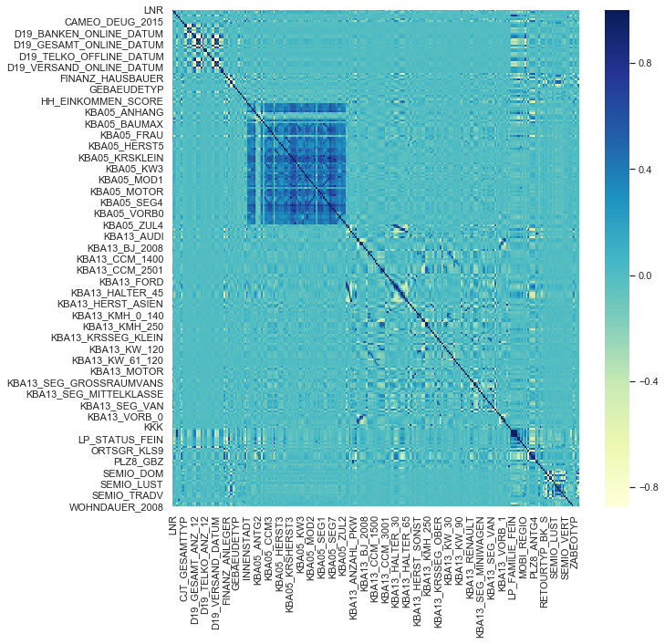

```
Columns dropped due to high correlation: 16 ['D19_GESAMT_ANZ_24', 'D19_VERSAND_ANZ_12', 'D19_VERSAND_ANZ_24', 'D19_VERSAND_DATUM', 'D19_VERSAND_ONLINE_DATUM', 'D19_VERSAND_ONLINE_QUOTE_12', 'KBA05_KRSHERST2', 'KBA05_KRSHERST3', 'KBA05_SEG9', 'KBA13_HALTER_66', 'KBA13_HERST_SONST', 'KBA13_KMH_250', '…

3.1) Drop rows with missing values greater than 20%
```

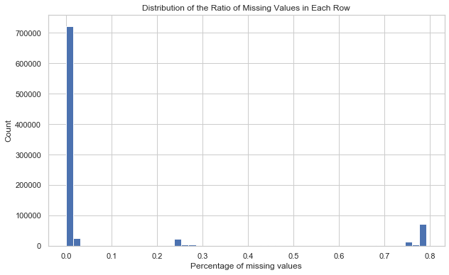

```
Rows dropped from the dataset: 139890

Extra column(s) dropped: ['FINANZ_SPARER', 'GEBAEUDETYP', 'TITEL_KZ']
Total 114 columns dropped
CPU times: user 7min 51s, sys: 15.3 s, total: 8min 7s
Wall time: 3min 6s
```

```python
%%time
azdias = data_cleaning(azdias, col_to_keep = ['LNR'], test_set = False)
```

```
1.1) Transform object to numeric-type columns
[Before transforming]
CAMEO_DEU_2015 : ['1A' nan '5D' '4C' '7B' '3B' '1D' '9E' '2D' '4A' '6B' '9D' '8B' '5C' '9C'
 '4E' '6C' '8C' '8A' '5B' '9B' '3D' '2A' '3C' '5F' '7A' '1E' '2C' '7C'
 '5A' '2B' '6D' '7E' '5E' '6E' '3A' '9A' '4B' '1C' '1B' '6A' '8D' '7D'
 '6F' '4D' 'XX']
CAMEO_DEUG_2015 : ['1' nan '5' '4' '7' '3' '9' '2' '6' '8' 'X']
CAMEO_INTL_2015 : ['13' nan '34' '24' '41' '23' '15' '55' '14' '22' '43' '51' '33' '25' '44'
 '54' '32' '12' '35' '31' '45' '52' 'XX']
D19_LETZTER_KAUF_BRANCHE : ['D19_UNBEKANNT' 'D19_BANKEN_GROSS' 'D19_NAHRUNGSERGAENZUNG' 'D19_SCHUHE'
 'D19_BUCH_CD' 'D19_DROGERIEARTIKEL' 'D19_SONSTIGE' 'D19_TECHNIK'
 'D19_VERSICHERUNGEN' 'D19_TELKO_MOBILE' 'D19_VOLLSORTIMENT' nan
 'D19_HAUS_DEKO' 'D19_ENERGIE' 'D19_REISEN' 'D19_BANKEN_LOKAL'
 'D19_VERSAND_REST' 'D19_BEKLEIDUNG_REST' 'D19_FREIZEIT'
 'D19_BEKLEIDUNG_GEH' 'D19_TELKO_REST' 'D19_SAMMELARTIKEL'
 'D19_BANKEN_DIREKT' 'D19_KINDERARTIKEL' 'D19_BANKEN_REST'
 'D19_LEBENSMITTEL' 'D19_GARTEN' 'D19_HANDWERK' 'D19_RATGEBER'
 'D19_DIGIT_SERV' 'D19_BIO_OEKO' 'D19_BILDUNG' 'D19_WEIN_FEINKOST'
 'D19_TIERARTIKEL' 'D19_LOTTO' 'D19_KOSMETIK']
EINGEFUEGT_AM : ['1992-02-12 00:00:00' nan '1992-02-10 00:00:00' ... '2008-04-25 00:00:00'
 '2005-03-30 00:00:00' '2008-07-14 00:00:00']
OST_WEST_KZ : ['W' nan 'O']
PRODUCT_GROUP : ['COSMETIC_AND_FOOD' 'FOOD' 'COSMETIC']
CUSTOMER_GROUP : ['MULTI_BUYER' 'SINGLE_BUYER']

[After transforming]
CAMEO_DEU_2015 : ['1A' nan '5D' '4C' '7B' '3B' '1D' '9E' '2D' '4A' '6B' '9D' '8B' '5C' '9C'
 '4E' '6C' '8C' '8A' '5B' '9B' '3D' '2A' '3C' '5F' '7A' '1E' '2C' '7C'
 '5A' '2B' '6D' '7E' '5E' '6E' '3A' '9A' '4B' '1C' '1B' '6A' '8D' '7D'
 '6F' '4D' 'XX']
CAMEO_DEUG_2015 : [ 1. nan  5.  4.  7.  3.  9.  2.  6.  8.]
CAMEO_INTL_2015 : [13. nan 34. 24. 41. 23. 15. 55. 14. 22. 43. 51. 33. 25. 44. 54. 32. 12.
 35. 31. 45. 52.]
D19_LETZTER_KAUF_BRANCHE : ['D19_UNBEKANNT' 'D19_BANKEN_GROSS' 'D19_NAHRUNGSERGAENZUNG' 'D19_SCHUHE'
 'D19_BUCH_CD' 'D19_DROGERIEARTIKEL' 'D19_SONSTIGE' 'D19_TECHNIK'
 'D19_VERSICHERUNGEN' 'D19_TELKO_MOBILE' 'D19_VOLLSORTIMENT' nan
 'D19_HAUS_DEKO' 'D19_ENERGIE' 'D19_REISEN' 'D19_BANKEN_LOKAL'
 'D19_VERSAND_REST' 'D19_BEKLEIDUNG_REST' 'D19_FREIZEIT'
 'D19_BEKLEIDUNG_GEH' 'D19_TELKO_REST' 'D19_SAMMELARTIKEL'
 'D19_BANKEN_DIREKT' 'D19_KINDERARTIKEL' 'D19_BANKEN_REST'
 'D19_LEBENSMITTEL' 'D19_GARTEN' 'D19_HANDWERK' 'D19_RATGEBER'
 'D19_DIGIT_SERV' 'D19_BIO_OEKO' 'D19_BILDUNG' 'D19_WEIN_FEINKOST'
 'D19_TIERARTIKEL' 'D19_LOTTO' 'D19_KOSMETIK']
EINGEFUEGT_AM : ['1992-02-12 00:00:00' nan '1992-02-10 00:00:00' ... '2008-04-25 00:00:00'
 '2005-03-30 00:00:00' '2008-07-14 00:00:00']
OST_WEST_KZ : ['W' nan 'O']
PRODUCT_GROUP : ['COSMETIC_AND_FOOD' 'FOOD' 'COSMETIC']
CUSTOMER_GROUP : ['MULTI_BUYER' 'SINGLE_BUYER']

1.2) Deal with unknown values

2.1) Drop columns not covered in the attribute or information dataset
Columns dropped due non coverage in the description files: 96 columns ['AKT_DAT_KL', 'ALTERSKATEGORIE_FEIN', 'ALTER_KIND1', 'ALTER_KIND2', 'ALTER_KIND3', 'ALTER_KIND4', 'ANZ_KINDER', 'ANZ_STATISTISCHE_HAUSHALTE', 'ARBEIT', 'CAMEO_INTL_2015', 'CJT_KATALOGNUTZER', 'CJT_TYP_1', 'CJT_TYP_2', 'CJT_TYP_3'…

2.2) Drop columns with missing values greater than 30% in the dataset
```

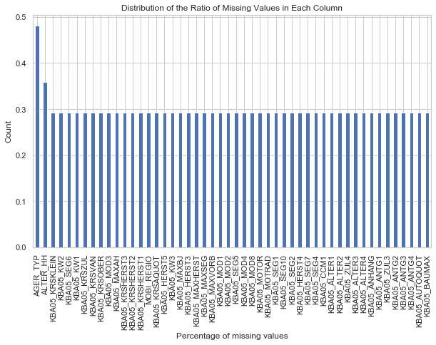

```
Columns dropped due to missing values: 2 ['AGER_TYP', 'ALTER_HH']

2.3) Drop highly correlated columns (corr > 90%)
```

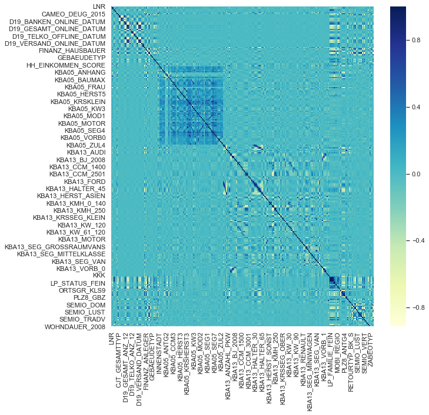

```
Columns dropped due to high correlation: 13 ['D19_GESAMT_ANZ_24', 'D19_VERSAND_ANZ_12', 'D19_VERSAND_ANZ_24', 'D19_VERSAND_ONLINE_DATUM', 'D19_VERSAND_ONLINE_QUOTE_12', 'FINANZ_SPARER', 'KBA13_HALTER_66', 'KBA13_HERST_SONST', 'KBA13_KMH_250', 'LP_FAMILIE_GROB', 'LP_LEBENSPHASE_FEIN', 'LP_LEBENSPHASE…

3.1) Drop rows with missing values greater than 20%
```

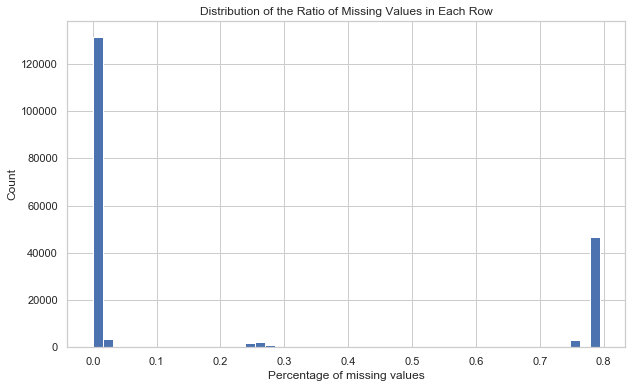

```
Rows dropped from the dataset: 56508

Extra column(s) dropped: ['KBA05_KRSHERST2', 'KBA05_SEG9', 'KBA05_KRSHERST3', 'D19_VERSAND_DATUM', 'GEBAEUDETYP', 'TITEL_KZ']
Total 117 columns dropped
CPU times: user 42.7 s, sys: 931 ms, total: 43.7 s
Wall time: 39.8 s
```

```python
%%time
customers = data_cleaning(customers, col_to_keep = ['LNR'], test_set = False)
```

### Checking results

```python
# Check object type columns
display(azdias.select_dtypes(include = ['object']).columns)
display(customers.select_dtypes(include = ['object']).columns)

# Check a unique value column: LNR
print(azdias.LNR.duplicated().sum(), customers.LNR.duplicated().sum())

# Check non-overlapping columns
## Initial results were below. So added additional step in the cleaning function
# ['FINANZ_SPARER']
# ['KBA05_KRSHERST2', 'KBA05_SEG9', 'KBA05_KRSHERST3', 'D19_VERSAND_DATUM']
display(list(set(azdias.columns) - set(customers.columns)))
display(list(set(customers.columns) - set(azdias.columns)))
```

```
Index(['CAMEO_DEU_2015', 'OST_WEST_KZ'], dtype='object')
```

```
Index(['CAMEO_DEU_2015', 'OST_WEST_KZ'], dtype='object')
```

```
0 0
```

```
[]
```

```
[]
```

```python
def azdias_customers_plot(column):
    '''
    Input: column
    Output: plot
    Process: plot the distribution of features in two dataset
    '''
    fig, (ax1, ax2) = plt.subplots(figsize = (10, 4), ncols = 2)
    # Plot azdias' column
    sns.countplot(x = column, data = azdias, ax = ax1, palette = "Set3")
    ax1.set_xlabel('Values')
    ax1.set_title('AZDIAS ' + column + ' feature')

    sns.countplot(x = column, data = customers, ax = ax2, palette = "Set3")
    ax2.set_xlabel('Values')
    ax2.set_title('CUSTOMERS ' + column + ' feature')
    fig.tight_layout()
    plt.show()
```

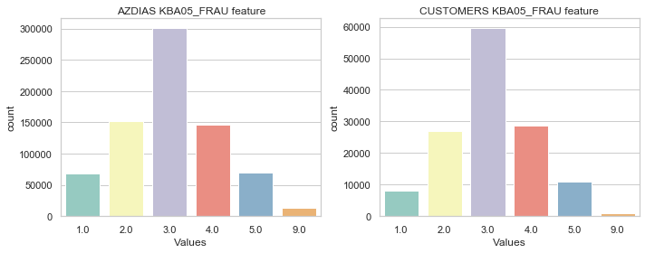

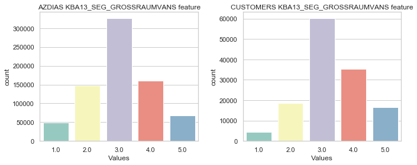

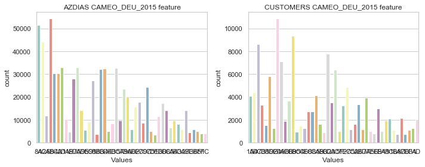

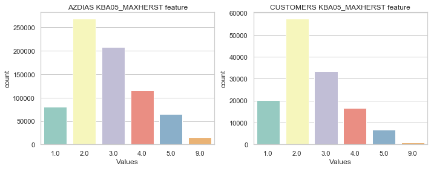

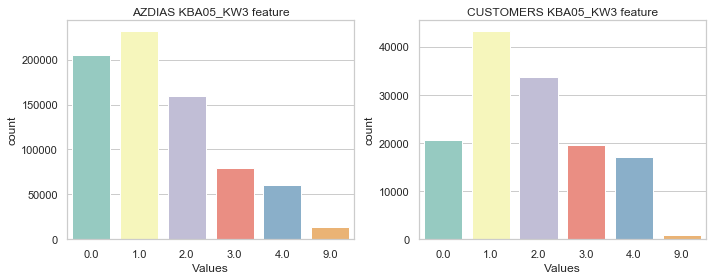

```python
# Plot distribution of randomly selected values from both datasets
for i in random.sample(range(0, len(azdias.columns) - 1), 5):
    azdias_customers_plot(azdias.columns[i])
```

### Step 5. Re-Encode Mixed and Categorical Features

1. Find numerical, categorical, ordinal, and mixed type columns using the description datasets provided.  
   To find numerical types, I used `numerical` as a keyword, `type, typology, typification, classification, CAMEO, flag` for categorical types, and assumed others as ordinal and mixed types.
2. Split information in the mixed type columns.  
   After exploring the result, I was able to find `PRAEGENDE_JUGENDJAHRE` holds two different information: decades and movement. Each information was extracted and separately stored in the dataset.
3. Transform to categorical variables: Instead of creating dummy variables, I decided transform object type columns only. At this stage, I have only two object type columns `CAMEO_DEU_2015` and `OST_WEST_KZ`, and I will convert these variables to the numeric type. Then in the dataset, I am expecting to have only `float` or `int` type columns.

```python
# For efficiency, keep the copy of cleaned datasets
azdias_cleaned = azdias.copy()
customers_cleaned = customers.copy()

# azdias = azdias_cleaned.copy()
# customers = customers_cleaned.copy()
```

```python
def get_info_types(df):
    ''' Using attribute description, classify columns into three different lists
    args:
    df; (dataframe) the dataset you want to check for
    return:
    numerical_col; (list) list of columns names of the numerical attributes
    categorical_col; (list) list of columns names of the categorical attributes
    ordinal_and_mixed_col; (list) list of columns names of the ordinal and mixed attributes
    '''
    # Numerical
    numerical_col = []
    for i, v in dias_attributes.iterrows():
        if v['Meaning'] is not np.nan:
            if 'numeric' in v['Meaning']:
                numerical_col.append(v['Attribute'])
    print(len(numerical_col), numerical_col)

    # Categorical
    categorical_description = ['type', 'typology', 'typification', 'classification', 'CAMEO', 'flag']
    categorical_col = []
    for i, v in dias_info.iterrows():
        if v['Description'] is not np.nan:
            if any(term in v['Description'] for term in categorical_description):
                categorical_col.append(v['Attribute'])

    categorical_col = list(set(df.columns) & set(categorical_col))
    print(len(categorical_col), categorical_col)

    # Ordinal and mixed
    ordinal_and_mixed_col = list(set(df.columns) - set(numerical_col) - set(categorical_col))
    print(len(ordinal_and_mixed_col), ordinal_and_mixed_col[:30])

    return numerical_col, categorical_col, ordinal_and_mixed_col
```

```python
# Split PRAEGENDE_JUGENDJAHRE into two variables
# Decade and movement (mainstream or avantgarde) info
def get_decade(value):
    ''' Get decade information from PRAEGENDE_JUGENDJAHRE feature
    input:
    value; (int) original value
    output:
    int; (int) converted value {0: 40's, 1: 50's, 2: 60's, 3: 70's, 4: 80's, 5: 90's}
    '''
    if (value > 0 and value < 3): ## 40's
        return 0
    elif value < 5: ## 50's
        return 1
    elif value < 8: ## 60's
        return 2
    elif value < 10: ## 70's
        return 3
    elif value < 14: ## 80's
        return 4
    elif value <= 15: ## 90's
        return 5
```

```python
def transform_categorical_mixed(df):

    # Get data info types
    numerical_col, categorical_col, ordinal_and_mixed_col = get_info_types(df)

    # Mixed type
    ## Transform mixed-type PRAEGENDE_JUGENDJAHRE to two categorical variables
    print('Transform mixed-type PRAEGENDE_JUGENDJAHRE to two categorical variables')
    ## DECADE; 0: 40's, 1: 50's, 2: 60's, 3: 70's, 4: 80's, 5: 90's
    df['DECADE'] = df['PRAEGENDE_JUGENDJAHRE'].apply(lambda x: get_decade(x))
    ## MOVEMENT; 1: Mainstream / 0: Avantgarde
    df.loc[df['PRAEGENDE_JUGENDJAHRE'].isin([1,3,5,8,10,12,14]), 'MOVEMENT'] = 1
    df.loc[df['PRAEGENDE_JUGENDJAHRE'].isin([2,4,6,7,9,11,13,15]), 'MOVEMENT'] = 0
    ## update column lists and drop original column (PRAEGENDE_JUGENDJAHRE)
    categorical_col.extend(['DECADE', 'MOVEMENT'])
    ordinal_and_mixed_col.remove('PRAEGENDE_JUGENDJAHRE')
    df.drop('PRAEGENDE_JUGENDJAHRE', axis = 1, inplace = True)

    # Categorical type
    ## Check if the column in the two datasets have different number of unique values
#     print('\nCross-check the number of unique values in each column in the two datasets')
#     col_to_be_deleted = []
#     for col in categorical_col:
#         if azdias[col].nunique() != customers[col].nunique():
#             col_to_be_deleted.append(col)
#             categorical_col.remove(col)

    # df.drop(col_to_be_deleted, axis = 1, inplace = True)
    # categorical_col_final = [e for e in categorical_col if e not in col_to_be_deleted]
    # print('Columns dropped after cross-check:', col_to_be_deleted)

    # To prevent additionally deleted columns in the last step of data cleaning,
    # Check the column names to exist in both sets

    # print('\nGet dummy variables from categorical variables')
    # df = pd.get_dummies(df, columns = categorical_col, prefix = categorical_col, drop_first = False)
    object_col = df.select_dtypes(include = ['object']).columns
    for col in object_col:
        df[col] = df[col].astype('category').cat.codes

    return df
```

```python
azdias_object_col = azdias.select_dtypes(include = ['object']).columns
for col in azdias_object_col:
        print(col, ':', azdias[col].unique())

azdias.CAMEO_DEU_2015.astype('category').cat.codes
azdias.OST_WEST_KZ.astype('category').cat.codes
```

```
CAMEO_DEU_2015 : ['8A' '4C' '2A' '6B' '8C' '4A' '2D' '1A' '1E' '9D' '7A' '5D' '9E' '5C'
 '9B' '1B' '8B' '3D' nan '4E' '4B' '3C' '5A' '7B' '9A' '6D' '6E' '2C' '7C'
 '9C' '7D' '5E' '1D' '8D' '6C' '6A' '5B' '4D' '3A' '2B' '7E' '3B' '6F'
 '5F' '1C']
OST_WEST_KZ : ['W' 'O']
```

```
1         1
2         1
3         1
4         1
5         1
         ..
891216    1
891217    1
891218    1
891219    1
891220    1
Length: 751331, dtype: int8
```

```python
azdias = transform_categorical_mixed(azdias)
customers = transform_categorical_mixed(customers)
```

```
7 ['ANZ_HAUSHALTE_AKTIV', 'ANZ_HH_TITEL', 'ANZ_PERSONEN', 'ANZ_TITEL', 'GEBURTSJAHR', 'KBA13_ANZAHL_PKW', 'MIN_GEBAEUDEJAHR']
19 ['FINANZ_VORSORGER', 'FINANZ_UNAUFFAELLIGER', 'FINANZTYP', 'PLZ8_BAUMAX', 'FINANZ_MINIMALIST', 'D19_KONSUMTYP', 'SHOPPER_TYP', 'HEALTH_TYP', 'VERS_TYP', 'RETOURTYP_BK_S', 'KBA05_BAUMAX', 'ZABEOTYP', 'OST_WEST_KZ', 'CAMEO_DEUG_2015', 'FINANZ_ANLEGER', 'REGIOTYP', 'FINANZ_HAUSBAUER', 'LP_FAMILIE_FE…
226 ['KBA05_ALTER4', 'KBA05_FRAU', 'KBA13_FORD', 'KBA05_HERST3', 'KBA05_MAXSEG', 'KBA05_CCM1', 'KBA05_HERST5', 'KBA13_KRSHERST_AUDI_VW', 'KBA13_KRSSEG_VAN', 'KBA13_MAZDA', 'CJT_GESAMTTYP', 'KBA13_AUTOQUOTE', 'KKK', 'KBA13_KW_70', 'KBA13_CCM_1000', 'KBA13_KMH_140_210', 'KBA13_KRSZUL_NEU', 'KBA13_BJ_2…
Transform mixed-type PRAEGENDE_JUGENDJAHRE to two categorical variables
7 ['ANZ_HAUSHALTE_AKTIV', 'ANZ_HH_TITEL', 'ANZ_PERSONEN', 'ANZ_TITEL', 'GEBURTSJAHR', 'KBA13_ANZAHL_PKW', 'MIN_GEBAEUDEJAHR']
19 ['FINANZ_VORSORGER', 'FINANZ_UNAUFFAELLIGER', 'FINANZTYP', 'PLZ8_BAUMAX', 'FINANZ_MINIMALIST', 'D19_KONSUMTYP', 'SHOPPER_TYP', 'HEALTH_TYP', 'VERS_TYP', 'RETOURTYP_BK_S', 'KBA05_BAUMAX', 'ZABEOTYP', 'OST_WEST_KZ', 'CAMEO_DEUG_2015', 'FINANZ_ANLEGER', 'REGIOTYP', 'FINANZ_HAUSBAUER', 'LP_FAMILIE_FE…
226 ['KBA05_ALTER4', 'KBA05_FRAU', 'KBA13_FORD', 'KBA05_HERST3', 'KBA05_MAXSEG', 'KBA05_CCM1', 'KBA05_HERST5', 'KBA13_KRSHERST_AUDI_VW', 'KBA13_KRSSEG_VAN', 'KBA13_MAZDA', 'CJT_GESAMTTYP', 'KBA13_AUTOQUOTE', 'KKK', 'KBA13_KW_70', 'KBA13_CCM_1000', 'KBA13_KMH_140_210', 'KBA13_KRSZUL_NEU', 'KBA13_BJ_2…
Transform mixed-type PRAEGENDE_JUGENDJAHRE to two categorical variables
```

```python
display(azdias.info())
display(customers.info())
display(list(set(azdias.columns) - set(customers.columns)))
display(list(set(customers.columns) - set(azdias.columns)))
```

```
<class 'pandas.core.frame.DataFrame'>
Int64Index: 751331 entries, 1 to 891220
Columns: 253 entries, LNR to MOVEMENT
dtypes: float64(206), int64(45), int8(2)
memory usage: 1.4 GB
```

```
None
```

```
<class 'pandas.core.frame.DataFrame'>
Int64Index: 135144 entries, 0 to 191651
Columns: 253 entries, LNR to MOVEMENT
dtypes: float64(206), int64(45), int8(2)
memory usage: 265.1 MB
```

```
None
```

```
[]
```

```
[]
```

```python
# Not necessary
# azdias = azdias.astype(int)
# customers = customers.astype(int)
```

```python
# Results when transforming categorical to dummy variables
display(azdias.info())
display(customers.info())
display(list(set(azdias.columns) - set(customers.columns)))
display(list(set(customers.columns) - set(azdias.columns)))
```

```
<class 'pandas.core.frame.DataFrame'>
Int64Index: 751331 entries, 1 to 891220
Columns: 253 entries, LNR to MOVEMENT
dtypes: float64(206), int64(45), int8(2)
memory usage: 1.4 GB
```

```
None
```

```
<class 'pandas.core.frame.DataFrame'>
Int64Index: 135144 entries, 0 to 191651
Columns: 253 entries, LNR to MOVEMENT
dtypes: float64(206), int64(45), int8(2)
memory usage: 265.1 MB
```

```
None
```

```
[]
```

```
[]
```

### Step 6. Filling Missing Values and Scaling

1. Fill in missing values with `mode`: For the purpose of using in PCA, missing values needs to be filled. As the majority of variable type is either categorical or ordinal, I decided to use `mode` instead of using other descriptive values such as `median` or `mean`.
2. Scale each column using standard scaler: Scaling is needed to prevent few variables dominating in the model.

```python
azdias.set_index('LNR', inplace = True)
customers.set_index('LNR', inplace = True)
```

```python
# Impute nans with mode value of each column
# Apply feature scaling to the general population and customers' demographics data.
## Initiate imputer and scaler object
imputer = SimpleImputer(missing_values = np.nan, strategy = 'most_frequent')
scaler = StandardScaler()

## General population
azdias_imputed = imputer.fit_transform(azdias)
azdias_imputed_scaled = scaler.fit_transform(azdias_imputed)
azdias_imputed_scaled = pd.DataFrame(azdias_imputed_scaled,
                                     index = azdias.index.tolist(),
                                     columns = azdias.columns.tolist())
## Customers
customers_imputed = imputer.fit_transform(customers)
customers_imputed_scaled = scaler.fit_transform(customers_imputed)
customers_imputed_scaled = pd.DataFrame(customers_imputed_scaled,
                                        index = customers.index.tolist(),
                                        columns = customers.columns.tolist())

display(azdias_imputed_scaled.head())
display(customers_imputed_scaled.head())
```

|  | ANZ_HAUSHALTE_AKTIV | ANZ_HH_TITEL | ANZ_PERSONEN | ANZ_TITEL | BALLRAUM | CAMEO_DEU_2015 | CAMEO_DEUG_2015 | CJT_GESAMTTYP | D19_BANKEN_ANZ_12 | D19_BANKEN_ANZ_24 | D19_BANKEN_DATUM | D19_BANKEN_OFFLINE_DATUM | D19_BANKEN_ONLINE_DATUM | D19_BANKEN_ONLINE_QUOTE_12 | D19_GESAMT_ANZ_12 | D19_GESAMT_DATUM | D19_GESAMT_OFFLINE_DATUM | D19_GESAMT_ONLINE_DATUM | D19_GESAMT_ONLINE_QUOTE_12 | D19_KONSUMTYP | D19_TELKO_ANZ_12 | D19_TELKO_ANZ_24 | D19_TELKO_DATUM | D19_TELKO_OFFLINE_DATUM | D19_TELKO_ONLINE_DATUM | D19_VERSAND_OFFLINE_DATUM | D19_VERSI_ANZ_12 | D19_VERSI_ANZ_24 | EWDICHTE | … |
| --- | --- | --- | --- | --- | --- | --- | --- | --- | --- | --- | --- | --- | --- | --- | --- | --- | --- | --- | --- | --- | --- | --- | --- | --- | --- | --- | --- | --- | --- | --- |
| 910220 | 0.159045 | -0.128345 | 0.233463 | -0.06062 | 0.851626 | 0.901478 | 0.958681 | 0.981578 | -0.236314 | -0.304611 | 0.439296 | 0.126466 | 0.376131 | -0.238122 | -0.626140 | 0.975713 | 0.571725 | 0.805268 | -0.620864 | 0.850383 | -0.183417 | -0.260952 | 0.443785 | 0.239479 | 0.078008 | 0.482109 | -0.270566 | -0.347971 | -0.568194 | … |
| 910225 | 0.095201 | -0.128345 | -0.626760 | -0.06062 | -0.975220 | -0.699466 | -0.646583 | -0.323591 | -0.236314 | -0.304611 | 0.439296 | 0.126466 | 0.376131 | -0.238122 | -0.626140 | 0.975713 | 0.571725 | 0.805268 | -0.620864 | 0.850383 | -0.183417 | -0.260952 | 0.443785 | 0.239479 | 0.078008 | 0.482109 | -0.270566 | -0.347971 | 0.015347 | … |
| 910226 | -0.479387 | -0.128345 | -1.486983 | -0.06062 | -0.061797 | -1.499938 | -1.449215 | -0.976176 | -0.236314 | -0.304611 | 0.439296 | 0.126466 | 0.376131 | -0.238122 | -0.626140 | 0.975713 | 0.571725 | 0.805268 | -0.620864 | 0.850383 | -0.183417 | -0.260952 | 0.443785 | 0.239479 | 0.078008 | 0.482109 | -0.270566 | -0.347971 | -1.151735 | … |
| 910241 | -0.351701 | -0.128345 | 1.953909 | -0.06062 | -0.975220 | 0.101006 | 0.156049 | 0.981578 | 5.209737 | 6.212344 | -2.367506 | 0.126466 | -2.768727 | 4.224225 | 3.817302 | -1.827654 | -1.635351 | -2.131329 | 1.691088 | -1.648828 | -0.183417 | 2.190123 | -2.445077 | -2.354302 | 0.078008 | -0.185952 | 1.959554 | 4.373891 | 0.598888 | … |
| 910244 | -0.224014 | -0.128345 | -0.626760 | -0.06062 | 0.851626 | 1.061572 | 0.958681 | -0.976176 | -0.236314 | -0.304611 | 0.439296 | 0.126466 | 0.376131 | -0.238122 | 0.114434 | -1.204683 | 0.571725 | -1.478752 | 1.691088 | -0.711624 | -0.183417 | -0.260952 | 0.443785 | 0.239479 | 0.078008 | 0.482109 | -0.270566 | -0.347971 | -1.151735 | … |

|  | ANZ_HAUSHALTE_AKTIV | ANZ_HH_TITEL | ANZ_PERSONEN | ANZ_TITEL | BALLRAUM | CAMEO_DEU_2015 | CAMEO_DEUG_2015 | CJT_GESAMTTYP | D19_BANKEN_ANZ_12 | D19_BANKEN_ANZ_24 | D19_BANKEN_DATUM | D19_BANKEN_OFFLINE_DATUM | D19_BANKEN_ONLINE_DATUM | D19_BANKEN_ONLINE_QUOTE_12 | D19_GESAMT_ANZ_12 | D19_GESAMT_DATUM | D19_GESAMT_OFFLINE_DATUM | D19_GESAMT_ONLINE_DATUM | D19_GESAMT_ONLINE_QUOTE_12 | D19_KONSUMTYP | D19_TELKO_ANZ_12 | D19_TELKO_ANZ_24 | D19_TELKO_DATUM | D19_TELKO_OFFLINE_DATUM | D19_TELKO_ONLINE_DATUM | D19_VERSAND_OFFLINE_DATUM | D19_VERSI_ANZ_12 | D19_VERSI_ANZ_24 | EWDICHTE | … |
| --- | --- | --- | --- | --- | --- | --- | --- | --- | --- | --- | --- | --- | --- | --- | --- | --- | --- | --- | --- | --- | --- | --- | --- | --- | --- | --- | --- | --- | --- | --- |
| 9626 | -0.281281 | -0.127178 | -0.202055 | -0.134423 | -0.611967 | -1.516419 | -1.403206 | 1.345549 | -0.253035 | -0.313175 | 0.451171 | 0.201598 | 0.334911 | -0.219095 | -0.843642 | 1.200120 | 0.479567 | 1.054822 | -0.759893 | -0.010304 | -0.21165 | -0.290615 | 0.472808 | 0.280072 | 0.096714 | 0.345185 | -0.300083 | -0.380055 | -1.178652 | … |
| 143872 | -0.281281 | -0.127178 | -0.915934 | -0.134423 | 1.277475 | 0.271494 | 0.273914 | -0.661421 | -0.253035 | -0.313175 | 0.451171 | 0.201598 | 0.334911 | -0.219095 | -0.843642 | 1.537043 | 0.916167 | 1.054822 | -0.759893 | -0.010304 | -0.21165 | -0.290615 | 0.472808 | 0.280072 | 0.096714 | 0.816608 | -0.300083 | -0.380055 | 0.067117 | … |
| 143873 | -0.352986 | -0.127178 | -1.629812 | -0.134423 | 1.277475 | -0.239338 | -0.145366 | -0.661421 | -0.253035 | -0.313175 | 0.451171 | 0.201598 | 0.334911 | -0.219095 | -0.843642 | 0.189351 | -0.830232 | 1.054822 | -0.759893 | -0.010304 | -0.21165 | -0.290615 | 0.472808 | 0.280072 | 0.096714 | -1.069084 | -0.300083 | -0.380055 | -1.801536 | … |
| 143874 | 0.148952 | -0.127178 | 1.225702 | -0.134423 | -0.611967 | 1.122881 | 1.112474 | 2.014539 | 1.864771 | 2.694587 | -3.356344 | 0.201598 | -1.592301 | -0.219095 | 1.218464 | -1.495264 | 0.042967 | -1.786386 | 1.443541 | -0.925568 | -0.21165 | 2.252438 | -1.612973 | 0.280072 | -3.315017 | -0.126238 | -0.300083 | -0.380055 | 0.067117 | … |
| 143888 | -0.281281 | -0.127178 | -0.202055 | -0.134423 | 1.277475 | 0.271494 | 0.273914 | 0.676559 | -0.253035 | -0.313175 | 0.451171 | 0.201598 | 0.334911 | -0.219095 | -0.843642 | 0.189351 | -0.830232 | 1.054822 | -0.759893 | -0.467936 | -0.21165 | -0.290615 | 0.472808 | 0.280072 | 0.096714 | -1.069084 | -0.300083 | -0.380055 | 0.690001 | … |

## Part 1: Customer Segmentation Report

The main bulk of your analysis will come in this part of the project. Here, you should use unsupervised learning techniques to describe the relationship between the demographics of the company's existing customers and the general population of Germany. By the end of this part, you should be able to describe parts of the general population that are more likely to be part of the mail-order company's main customer base, and which parts of the general population are less so.

### PCA (Principal Component Analysis) and K-Means Clustering

After the data cleaning, I obtained total 252 features. As the number is very large, I will use Principal Component Analysis (PCA) to reduce the dimension and select the number of features needed to explain about 80% of the variance.

To interpret principal components, I took the top three components and checked five highest weights both in positive and negative directions. From the first component, for example, it seems to be representing a combination of features that relate to cars and housing, which may implies the wealth of the area.

- PC1:
  - Positive
    - KBA05_SEG6 - share of upper class cars (BMW 7er etc.) in the microcell
    - KBA05_KRSOBER - share of upper class cars (referred to the county average)
    - KBA05_KRSVAN - share of vans (referred to the county average)
    - KBA05_KRSZUL - share of newbuilt cars (referred to the county average)
    - KBA05_SEG8 - share of roadster and convertables in the microcell
  - Negative
    - KBA05_ANTG3 - number of 6-10 family houses in the cell
    - FINANZ_ANLEGER - financial typology: investor
    - KBA05_ANTG2 - number of 3-5 family houses in the cell
    - KBA13_KW_0_60 - share of cars up to 60 KW engine power - PLZ8
    - DECADE - decade information extracted from `PRAEGENDE_JUGENDJAHRE - dominating movement in the person's youth (avantgarde or mainstream)`

- Material, traditional, and rational-minded (SEMIO_MAT, SEMIO_TRADV, SEMIO_RAT)
- Religious and familiar minded (SEMIO_REL, SEMIO_FAM)
- Financially less prepared (FINANZTYP, FINANZ_VORSORGER)

```python
def perform_pca(df, n_components = None):
    ''' Transforms data using PCA to create n_components,
    and return the results of the transformation.

    args:
    df; (dataframe) the dataset to be transformed
    n_components; (int or None) the number of principal components to create

    return:
    pca - the pca object
    df_fit - the transformed array with new number of components
    '''

    # X = df.copy()
    # Use specified number of components to create the pca object
    if n_components != None:
        pca = PCA(n_components, random_state = 42)
    else:
        pca = PCA(random_state = 42)

    # Fit the data into PCA
    df_fit = pca.fit_transform(df)

    return pca, df_fit
```

```python
def plot_variance_ratio(pca):
    ''' Create a scree plot associated with the principal components
    args:
    pca; (object) the pca object
    '''
    # Values to be plotted
    values = pca.explained_variance_ratio_
    x_axis = np.arange(len(values))

    # Plot
    plt.figure(figsize = (16, 10))
    ax = plt.subplot(111)
    ax.bar(x_axis, values)
    ax.set_axisbelow(True)
    ax.grid(linewidth = '0.5', alpha = 0.5)
    ax.xaxis.set_tick_params(width = 0)
    ax.yaxis.set_tick_params(width = 2, length = 12)
    ax.set_xlabel("Principal Components")
    ax.set_ylabel("Variance Explained (%)")
    plt.title('Explained Variance Per Principal Component')

    # Print percentage of variance explained by first 5 components.
    for i in range(x_axis[5]):
        ax.annotate(r"%s%%" % ((str(values[i]*100)[:4])),
                    (x_axis[i] + 0.2, values[i]),
                    va = "bottom", ha = "center", fontsize = 12)
```

```python
def plot_cumulative_variance(pca):
    ''' Create a plot with cumulative variance with corresponding
        number of components used
    args:
    pca; (object) the pca object
    '''
    # Values to be plotted
    values = pca.explained_variance_ratio_
    cumulated_values = np.cumsum(values)
    x_axis = np.arange(len(values))
    plot_line_x = []
    plot_line_y = []
    for i in np.arange(0.3, max(cumulated_values), 0.1):
        # min(max(cumulated_values)+0.1, 1.0)
        y_val = cumulated_values[cumulated_values >= i][0]
        x_val = np.where(cumulated_values == y_val)[0][0]
        plot_line_x.append(x_val)
        plot_line_y.append(y_val)
        # print(i, x_val, y_val)

    # Plot
    plt.figure(figsize = (16, 10))
    ax = plt.subplot(111)
    ax.bar(x_axis, values) # Not necessary
    ax.plot(x_axis, cumulated_values)
    ax.set_axisbelow(True)
    ax.grid(linewidth = '0.5', alpha = 0.5)
    ax.xaxis.set_tick_params(width = 0)
    ax.yaxis.set_tick_params(width = 2, length = 12)
    ax.set_xlabel("Principal Components")
    ax.set_ylabel("Variance Explained (%)")
    plt.title('Cumulative Variance of Principal Components')

    # Plot horizontal and vertical at points with cumulative variance of 30% ~ 90%.
    for x_val, y_val in zip(plot_line_x, plot_line_y):
        plt.hlines(y = y_val, xmin = 0, xmax = x_val,
                   color = 'red', linestyles = 'dashed', zorder = 1)
        plt.vlines(x = x_val, ymin = 0, ymax = y_val,
                   color = 'red', linestyles = 'dashed', zorder = 2)

    # Print number of components for cumulative variance of 30% ~ 90%.
    for i, v in enumerate(plot_line_x):
        ax.annotate(r"%s" % ((str(v + 1))), (v + 0.2, np.round(plot_line_y[i], 2)),
                    va = "bottom", ha = "center", fontsize = 12)
```

```python
def plot_pca_results(df, pca, component_num):
    ''' Plot the weights of each variable from selected component
    args:
    df; (dataframe) the data fitted into the given PCA model
    pca; (object) the pca object
    component_num; (int) Component number to be plotted
    '''
    # Indexing
    dimensions = ['PC {}'.format(i) for i in range(1, len(pca.components_)+1, 1)]

    # PCA components
    components = pd.DataFrame(np.round(pca.components_, 4),
                              columns = df.keys(), index = dimensions)

    # PCA explained variance
    ratios = pca.explained_variance_ratio_.reshape(len(pca.components_), 1)
    variance_ratios = pd.DataFrame(np.round(ratios, 4),
                                   columns = ['Explained Variance'], index = dimensions)

    # Create a bar plot visualization
    fig, ax = plt.subplots(2, 1, figsize = (20, 14))
    plt.subplots_adjust(hspace = 0.45)
    fig.suptitle("PC {} - Explained Variance {:.4f}".format(component_num,
                                                            pca.explained_variance_ratio_[component_num - 1]),
                 fontsize = 20)

    # Plot the feature weights as a function of the components
    weight = components.iloc[component_num - 1]
    pos = weight[weight > 0].sort_values(ascending = False)
    pos.plot(kind = "bar", ax = ax[0]) # .sort_values(ascending = False)
    neg = weight[weight < 0].sort_values()
    neg.plot(kind = "bar", ax = ax[1])
    ax[0].set_ylabel("Feature Weights")
    ax[1].set_ylabel("Feature Weights")
    plt.show()

    # Print top and bottom 5 values in the component
    print(pos[:5], '\n', neg[:5])
```

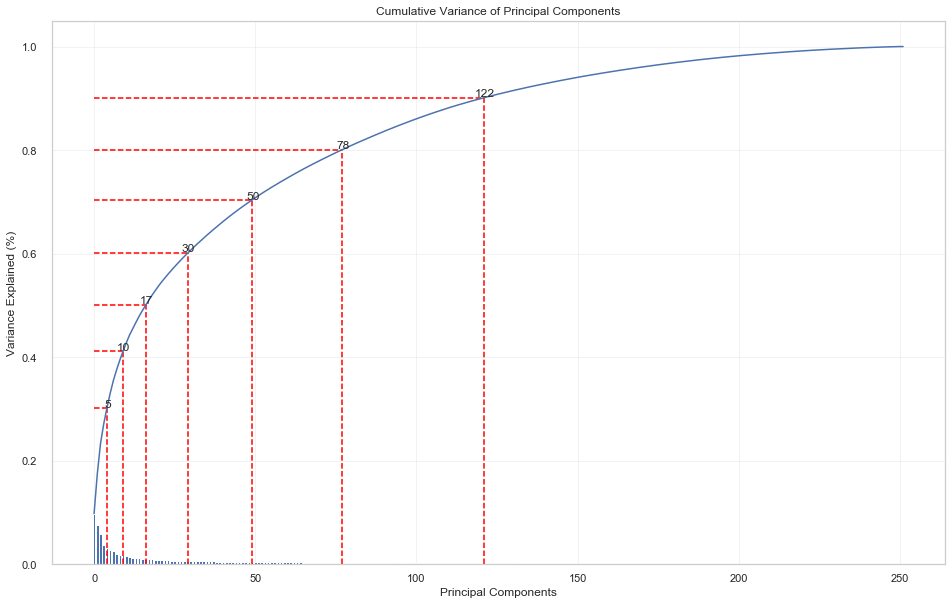

```python
# Using entire components
pca, azdias_pca = perform_pca(azdias_imputed_scaled)
plot_cumulative_variance(pca)
```

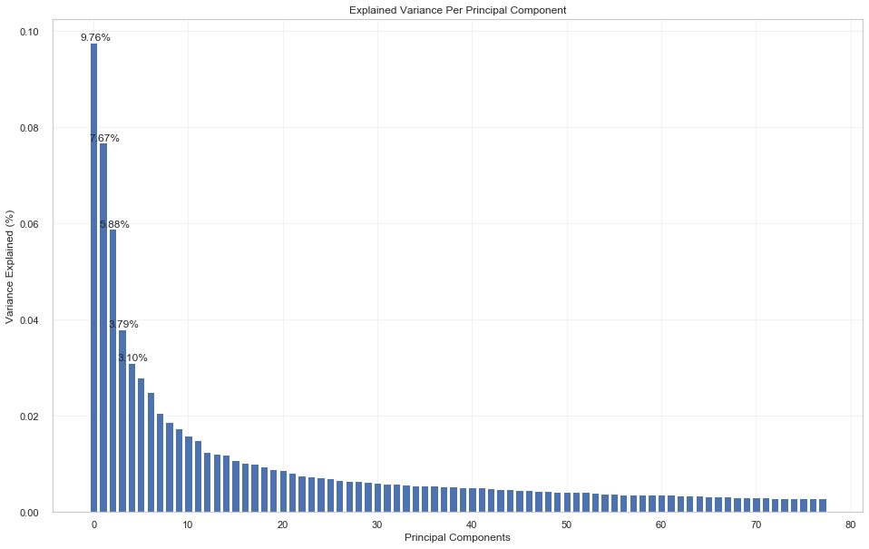

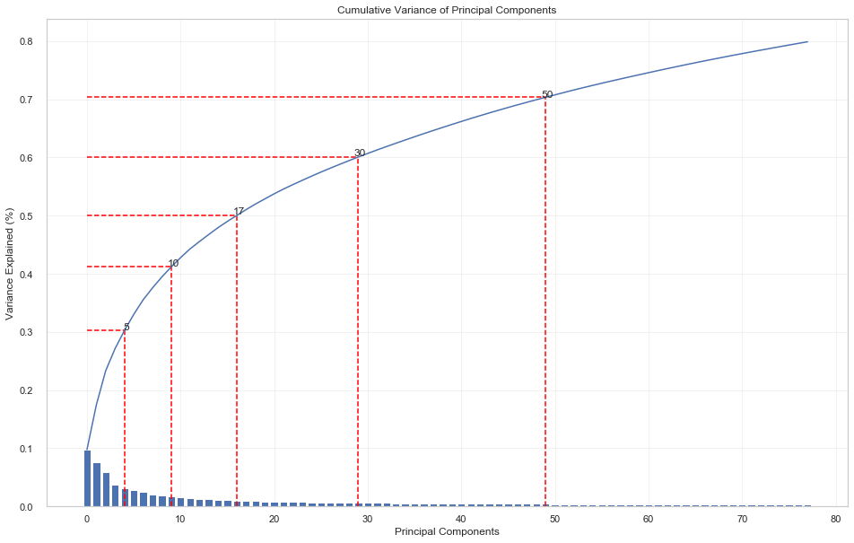

```python
# Using 78 components, which explains approximately 80%
pca_78, azdias_pca_78 = perform_pca(azdias_imputed_scaled, n_components = 78)
plot_variance_ratio(pca_78)
plot_cumulative_variance(pca_78)
```

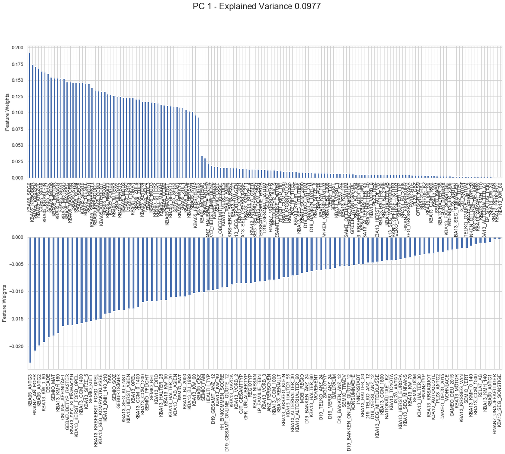

```
KBA05_SEG6       0.1931
KBA05_KRSOBER    0.1747
KBA05_KRSVAN     0.1716
KBA05_KRSZUL     0.1689
KBA05_SEG8       0.1632
Name: PC 1, dtype: float64
 KBA05_ANTG3      -0.0231
FINANZ_ANLEGER   -0.0209
KBA05_ANTG2      -0.0199
KBA13_KW_0_60    -0.0193
DECADE           -0.0184
Name: PC 1, dtype: float64
```

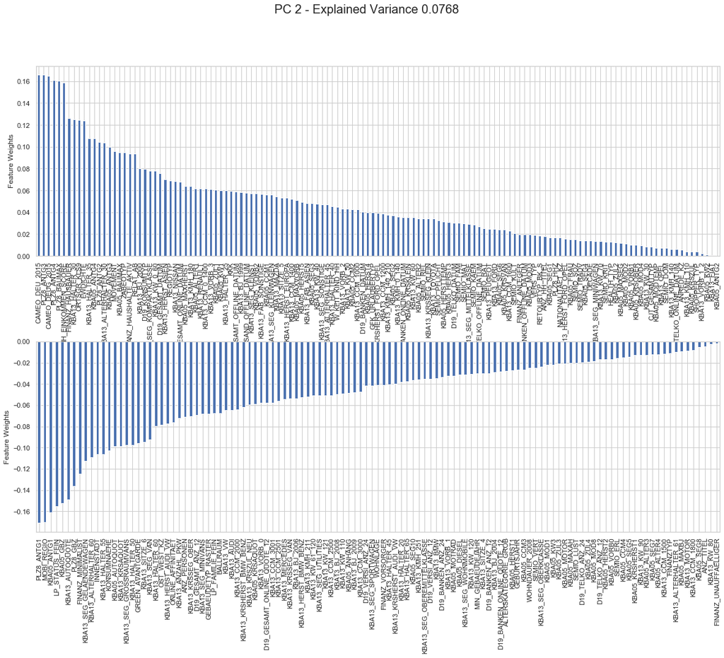

```
CAMEO_DEU_2015     0.1658
PLZ8_ANTG3         0.1657
CAMEO_DEUG_2015    0.1651
PLZ8_ANTG4         0.1608
PLZ8_BAUMAX        0.1601
Name: PC 2, dtype: float64
 PLZ8_ANTG1       -0.1707
MOBI_REGIO       -0.1703
KBA05_ANTG1      -0.1609
LP_STATUS_FEIN   -0.1551
KBA05_GBZ        -0.1523
Name: PC 2, dtype: float64
```

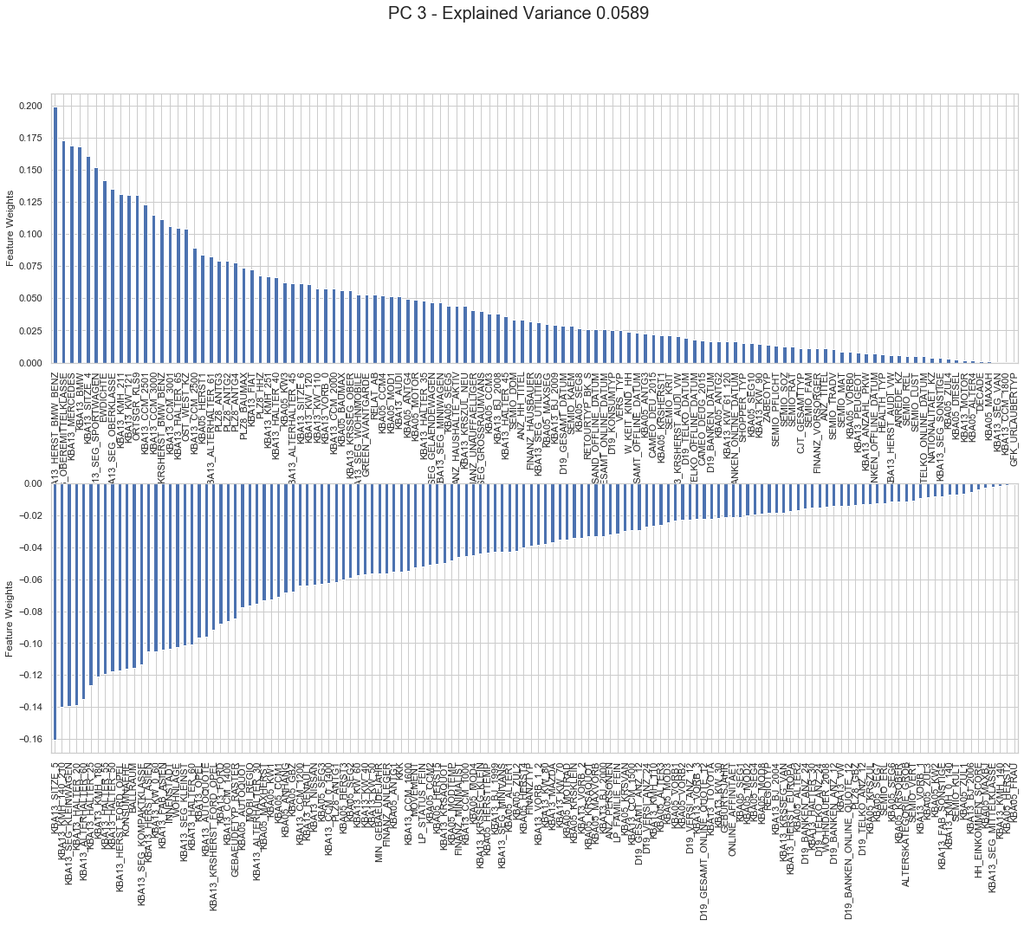

```
KBA13_HERST_BMW_BENZ           0.1995
KBA13_SEG_OBEREMITTELKLASSE    0.1733
KBA13_MERCEDES                 0.1687
KBA13_BMW                      0.1683
KBA13_SITZE_4                  0.1610
Name: PC 3, dtype: float64
 KBA13_SITZE_5          -0.1607
KBA13_KMH_140_210      -0.1400
KBA13_SEG_KLEINWAGEN   -0.1395
KBA13_HALTER_20        -0.1388
KBA13_ALTERHALTER_60   -0.1352
Name: PC 3, dtype: float64
```

```python
plot_pca_results(azdias_imputed_scaled, pca_78, 1)
plot_pca_results(azdias_imputed_scaled, pca_78, 2)
plot_pca_results(azdias_imputed_scaled, pca_78, 3)
```

```python
print("original shape:   ", azdias_imputed_scaled.shape)
print("transformed shape:", azdias_pca_78.shape)
```

```
original shape:    (751331, 252)
transformed shape: (751331, 78)
```

```python
# Fit the customers data
customers_pca_78 = pca_78.transform(customers_imputed_scaled)

print("original shape:   ", customers_imputed_scaled.shape)
print("transformed shape:", customers_pca_78.shape)
```

```
original shape:    (135144, 252)
transformed shape: (135144, 78)
```

```python
def get_kmeans_score(df, center):
    '''Calculate the kmeans score regarding SSE for points to centers
    args:
    df; (dataframe) the dataset you want to fit kmeans to
    center; (int) the number of centers you want to have

    return:
    score - the SSE score for the fitted kmeans model
    '''
    # Initiate K-Means object
    kmeans = KMeans(n_clusters = center)
    # Fit the model to the data
    model = kmeans.fit(df)
    # Obtain a score related to the model fit
    score = np.abs(model.score(df))

    return score
```

```python
%%time
center_list = list(range(2, 21, 1))
azdias_scores = []
for center in center_list:
    score = round(get_kmeans_score(azdias_pca_78, center), 2)
    print('center : {} / score : {}'.format(center, score))
    azdias_scores.append(score)

# customers_scores = []
# for center in center_list:
#     score = round(get_kmeans_score(customers_pca_78, center), 2)
#     print('center : {} / score : {}'.format(center, score))
#     customers_scores.append(score)
```

```
center : 2 / score : 140505156.42
center : 3 / score : 122842822.19
center : 4 / score : 118155723.51
center : 5 / score : 114675405.7
center : 6 / score : 112091517.28
center : 7 / score : 110003684.17
center : 8 / score : 108375483.43
center : 9 / score : 106848813.23
center : 10 / score : 105596700.75
center : 11 / score : 104532354.21
center : 12 / score : 103688313.11
center : 13 / score : 102931253.52
center : 14 / score : 102238381.56
center : 15 / score : 101562514.48
center : 16 / score : 101146795.53
center : 17 / score : 100464534.35
center : 18 / score : 99996004.07
center : 19 / score : 99560900.42
center : 20 / score : 99156946.74
CPU times: user 1h 29min 54s, sys: 4min 2s, total: 1h 33min 56s
Wall time: 1h 11min 53s
```

```python
# Create dataframe showing the average point-centroid distances
azdias_avg_distance = np.array(azdias_scores) / azdias_pca_78.shape[0]
scores_df = pd.DataFrame({'cluster': center_list,
                          'azdias_score': azdias_scores,
                          'azdias_avg_distance': azdias_avg_distance})

# customers_avg_distance = np.array(customers_scores) / customers_pca_78.shape[0]
# scores_df = pd.DataFrame({'cluster': center_list,
#                           'azdias_score': azdias_scores,
#                           'azdias_avg_distance': azdias_avg_distance,
#                           'customers_score': customers_scores,
#                           'customers_avg_distance': customers_avg_distance})
display(scores_df.head())
```

|  | cluster | azdias_score | azdias_avg_distance |
| --- | --- | --- | --- |
| 0 | 2 | 1.405052e+08 | 187.008331 |
| 1 | 3 | 1.228428e+08 | 163.500271 |
| 2 | 4 | 1.181557e+08 | 157.261877 |
| 3 | 5 | 1.146754e+08 | 152.629674 |
| 4 | 6 | 1.120915e+08 | 149.190593 |

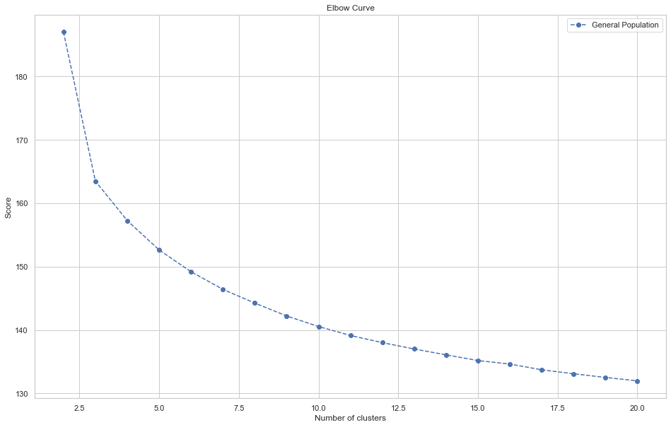

```python
plt.figure(figsize = (16, 10))
plt.plot(scores_df.cluster, scores_df.azdias_avg_distance,
         linestyle = '--', marker = 'o', color = 'b', label = 'General Population')
# plt.plot(scores_df.cluster, scores_df.customers_avg_distance,
#          linestyle = '--', marker = 'o', color = 'r', label = 'Customers')

plt.xlabel('Number of clusters')
plt.ylabel('Score')
plt.title('Elbow Curve')
plt.legend()
plt.show()
```

```python
# Get the optimal K-Means model
n_clusters = 10
kmeans_final = KMeans(n_clusters = n_clusters, random_state = 42)

# For the general population, fit and predict the data
azdias_pred = kmeans_final.fit_predict(azdias_pca_78)
# For the customers, fit and predict the data
customers_pred = kmeans_final.fit_predict(customers_pca_78)
```

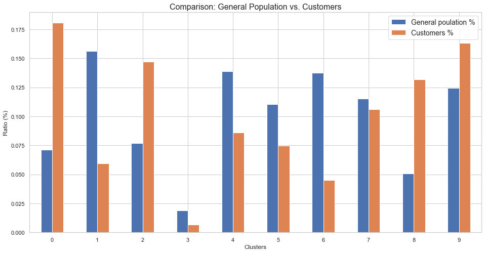

```python
# Compare the proportion of data in each cluster
azdias_proportion = []
customers_proportion = []
clusters = [i for i in range(n_clusters)]

for i in range(n_clusters):
    azdias_proportion.append((azdias_pred == i).sum() / len(azdias_pred))
    customers_proportion.append((customers_pred == i).sum() / len(customers_pred))

# Combine results into dataframe
df_cluster = pd.DataFrame({'clusters' : clusters,
                           'azdias_proportion': azdias_proportion,
                           'customers_proportion': customers_proportion})
# Plot results
df_cluster.plot(x = 'clusters',
                y = ['azdias_proportion', 'customers_proportion'],
                kind = 'bar', figsize = (16, 8))
plt.legend(('General poulation %', 'Customers %'), fontsize = 14)
plt.xticks(rotation = 360)
plt.xlabel('Clusters')
plt.ylabel('Ratio (%)')
plt.title('Comparison: General Population vs. Customers', fontsize = 16)
plt.show()
```

```python
# Check components' effect toward the cluster 0
cluster_0 = customers_pred[customers_pred == 0]
distance = (cluster_0.mean(axis = 0) - azdias_pca_78.mean(axis = 0)) / azdias_pca_78.std(axis = 0)

comp_significance = pd.DataFrame({'component': range(azdias_pca_78.shape[1]),
                                  'distance': distance,
                                  'abs_distance': np.abs(distance)})

comp_significance.sort_values(by = 'abs_distance', inplace = True)
display(comp_significance.head())
```

|  | component | distance | abs_distance |
| --- | --- | --- | --- |
| 55 | 55 | -2.892999e-18 | 2.892999e-18 |
| 27 | 27 | -1.429442e-17 | 1.429442e-17 |
| 3 | 3 | 1.572253e-17 | 1.572253e-17 |
| 16 | 16 | 2.742655e-17 | 2.742655e-17 |
| 47 | 47 | 2.892646e-17 | 2.892646e-17 |

```python
import operator
weight_list = {}
for i, feature in enumerate(azdias_imputed_scaled.columns.tolist()):
    weight_list[feature] = pca_78.components_[comp_significance.iloc[0, 0]][i]

weight_list = sorted(weight_list.items(), key = operator.itemgetter(1), reverse = True)
display(weight_list)
```

```
[('D19_TELKO_OFFLINE_DATUM', 0.20727848852154576),
 ('KBA05_ANTG2', 0.0657845567387897),
 ('ANZ_HAUSHALTE_AKTIV', 0.06426538163609419),
 ('D19_TELKO_DATUM', 0.062451926845380354),
 ('WOHNDAUER_2008', 0.05717418236892633),
 ('KBA13_MAZDA', 0.054261112027848016),
 ('KBA05_ALTER2', 0.050876944371759054),
 ('HEALTH_TYP', 0.04261852568767474),
 ('KBA13_MOTOR', 0.04105073060758876),
 ('KBA13_KRSHERST_AUDI_VW', 0.040888783570266186),
 ('KBA13_SEG_SPORTWAGEN', 0.03861424450476774),
 ('KBA13_KRSAQUOT', 0.03830794426637139),
 ('KBA13_RENAULT', 0.037549654197409),
 ('D19_VERSI_ANZ_12', 0.03482032556183592),
 ('ANZ_HH_TITEL', 0.03437608835336078),
 ('KBA05_HERST3', 0.033936157456794395),
 ('FINANZ_UNAUFFAELLIGER', 0.033549103125927515),
 ('KBA13_SEG_SONSTIGE', 0.03216823897399453),
 ('KBA13_CCM_3000', 0.031638163090748996),
 ('DECADE', 0.0300293097597576),
 ('ZABEOTYP', 0.02856731637372932),
 ('D19_VERSI_ANZ_24', 0.027697033043090995),
 ('KBA13_SEG_KOMPAKTKLASSE', 0.02755028007969125),
 ('KBA13_AUTOQUOTE', 0.02720249833255709),
 ('PLZ8_ANTG1', 0.02646253106093189),
 ('KBA13_HERST_EUROPA', 0.02594070934211799),
 ('D19_BANKEN_ANZ_24', 0.025067717025126918),
 ('D19_BANKEN_ANZ_12', 0.024844903343520366),
 ('KBA13_KW_110', 0.023853798151068344),
 ('D19_GESAMT_ONLINE_DATUM', 0.022697581966372518),
 ('GEBURTSJAHR', 0.022217480679329896),
 ('KBA05_ANTG4', 0.02140264584989052),
 ('KBA05_MOD4', 0.021115650604116836),
 ('KBA13_FAB_ASIEN', 0.019639600740908876),
 ('KBA13_BMW', 0.019482619963144897),
 ('SEMIO_DOM', 0.01920925926474631),
 ('KBA13_KW_80', 0.01834857758175031),
 ('SHOPPER_TYP', 0.017768237313855982),
 ('KBA05_MOD2', 0.017152763688227993),
 ('NATIONALITAET_KZ', 0.01680418643474005),
```

[output cut: 197 more lines]

```
 ('KBA05_BAUMAX', -0.036737389477129304),
 ('PLZ8_ANTG4', -0.03680680054729343),
 ('D19_GESAMT_ONLINE_QUOTE_12', -0.04127360690140754),
 ('FINANZ_VORSORGER', -0.0412809968328476),
 ('D19_GESAMT_OFFLINE_DATUM', -0.04443662768315307),
 ('GEBAEUDETYP_RASTER', -0.046108288918366706),
 ('D19_TELKO_ANZ_12', -0.055875772438290415),
 ('KBA13_KMH_251', -0.06007510647371572),
 ('KBA05_ALTER3', -0.06511084311169069),
 ('KBA05_ANTG3', -0.0761922319391661),
 ('D19_VERSAND_OFFLINE_DATUM', -0.08401643380932051),
 ('ANZ_TITEL', -0.1031237034781863),
 ('GFK_URLAUBERTYP', -0.13511483720401818),
 ('D19_BANKEN_OFFLINE_DATUM', -0.15205341787193868),
 ('D19_TELKO_ONLINE_DATUM', -0.8878813184766784)]
```

```python
weight_list_2 = {}
for i, feature in enumerate(azdias_imputed_scaled.columns.tolist()):
    weight_list_2[feature] = pca_78.components_[comp_significance.iloc[2, 0]][i]

weight_list_2 = sorted(weight_list_2.items(), key = operator.itemgetter(1), reverse = True)
display(weight_list_2)
```

```
[('DECADE', 0.2227973170936289),
 ('SEMIO_REL', 0.21492643960852914),
 ('ONLINE_AFFINITAET', 0.2116527769204801),
 ('SEMIO_PFLICHT', 0.20368507518179027),
 ('SEMIO_TRADV', 0.19595579105117766),
 ('FINANZ_UNAUFFAELLIGER', 0.18819586215889225),
 ('SEMIO_KULT', 0.1796731270884414),
 ('D19_GESAMT_ANZ_12', 0.16686531156939488),
 ('FINANZ_ANLEGER', 0.16197907039038506),
 ('SEMIO_RAT', 0.1547179525230928),
 ('SEMIO_FAM', 0.15120621881852658),
 ('D19_GESAMT_ONLINE_QUOTE_12', 0.14720212751799763),
 ('D19_BANKEN_ANZ_24', 0.1393818140980438),
 ('SEMIO_MAT', 0.13423472573177328),
 ('CJT_GESAMTTYP', 0.1309174332684431),
 ('D19_BANKEN_ANZ_12', 0.128741181284857),
 ('D19_BANKEN_ONLINE_QUOTE_12', 0.12457743354786154),
 ('D19_TELKO_ANZ_24', 0.09968023693724881),
 ('D19_VERSI_ANZ_24', 0.09551650179424072),
 ('LP_FAMILIE_FEIN', 0.08592918724112544),
 ('SEMIO_SOZ', 0.08573004753584644),
 ('ANZ_PERSONEN', 0.085618308354919),
 ('D19_TELKO_ANZ_12', 0.0852942532931046),
 ('GEBURTSJAHR', 0.08289065770970402),
 ('D19_VERSI_ANZ_12', 0.08172982108641907),
 ('NATIONALITAET_KZ', 0.058952109610771464),
 ('HEALTH_TYP', 0.05455601582547113),
 ('GFK_URLAUBERTYP', 0.048780727341154774),
 ('KBA13_ALTERHALTER_45', 0.047806361575775225),
 ('KBA13_BJ_2000', 0.0455596869682577),
 ('KBA13_HALTER_40', 0.04425777027733537),
 ('KBA05_ALTER2', 0.042740681415587164),
 ('KBA05_VORB2', 0.0405569505129996),
 ('ZABEOTYP', 0.036402144462174324),
 ('SEMIO_VERT', 0.03629017194632426),
 ('KBA13_HALTER_45', 0.03588807261191011),
 ('KBA13_BJ_1999', 0.03470124152461955),
 ('KBA13_VORB_3', 0.03452890154348692),
 ('KBA05_MAXVORB', 0.03397711434233474),
 ('KBA13_HALTER_35', 0.03320794383748086),
```

[output cut: 197 more lines]

```
 ('SEMIO_KRIT', -0.08850314694108187),
 ('FINANZTYP', -0.09229018794935585),
 ('FINANZ_MINIMALIST', -0.10684163101644817),
 ('W_KEIT_KIND_HH', -0.12000591803869724),
 ('D19_TELKO_DATUM', -0.12398838570880835),
 ('D19_KONSUMTYP', -0.1283879047992273),
 ('RETOURTYP_BK_S', -0.14122431444232408),
 ('D19_BANKEN_ONLINE_DATUM', -0.14831328780629174),
 ('SEMIO_LUST', -0.15426046402267857),
 ('D19_GESAMT_DATUM', -0.1557042714754125),
 ('D19_BANKEN_DATUM', -0.1568756114367663),
 ('D19_GESAMT_ONLINE_DATUM', -0.16285937012290533),
 ('SEMIO_ERL', -0.1884880931403504),
 ('FINANZ_VORSORGER', -0.19749231197040257),
 ('ALTERSKATEGORIE_GROB', -0.2141964294192182)]
```

## Part 2: Supervised Learning Model

Now that you've found which parts of the population are more likely to be customers of the mail-order company, it's time to build a prediction model. Each of the rows in the "MAILOUT" data files represents an individual that was targeted for a mailout campaign. Ideally, we should be able to use the demographic information from each individual to decide whether or not it will be worth it to include that person in the campaign.

The "MAILOUT" data has been split into two approximately equal parts, each with almost 43 000 data rows. In this part, you can verify your model with the "TRAIN" partition, which includes a column, "RESPONSE", that states whether or not a person became a customer of the company following the campaign. In the next part, you'll need to create predictions on the "TEST" partition, where the "RESPONSE" column has been withheld.

### Metrics

A [Receiver Operating Characteristic (ROC) curve](https://en.wikipedia.org/wiki/Receiver_operating_characteristic) is created by plotting the true positive rate (TPR, proportion of actual customers that are labeled as so) against the false positive rate (FPR, proportion of non-customers labeled as customers). The plot shows the performance of a classification model at all classification thresholds. Area Under Curve (AUC) provides an aggregate measure of performance across all possible classification thresholds. One way of interpreting AUC is as the probability that the model ranks a random positive example more highly than a random negative example. Using AUC as an evaluation metric is desirable for the following two reasons:

- Scale-invariant: AUC measures how well predictions are ranked, rather than their absolute values.
- Classification-threshold-invariant: AUC measures the quality of the model's predictions irrespective of what classification threshold is chosen.

### Part 2 Results

In this part, the goal is to find out the optimal model using the training dataset. The following classification methods were used:

- Logistic Regression (Benchmark)
- Random Forest
- AdaBoost
- Gradient Boosting
- XGBoost
- LightBGM

For each method, I am using `GridSearchCV` and `Bayesian Optimization` to train and optimize the model by using a five-fold validation method. To evaluate the models, `Area Under Curve (AUC)` for the ROC curve is used.

Next, for the two methods, I used both `Cross Validation` and `Bayesian Optimization` method to try multiple combinations of parameters for hyperparameter-tuning and achieved. `Gradient Boosting` model improved to AUC of 0.6285 and `XGBoost` to AUC of 0.6265.

```python
# path = '/Users/hyeukjung/Desktop/Udacity/Data Science Nanodegree Term 2/data/Term2/capstone/arvato_data/'
# '../../data/Term2/capstone/arvato_data/'

mailout_train = pd.read_csv(path + 'Udacity_MAILOUT_052018_TRAIN.csv', sep = ';', low_memory = False)
```

```python
display(mailout_train.shape)
display(mailout_train.info())
display(mailout_train.head())
display(mailout_train.RESPONSE.value_counts())
```

```
(42962, 367)
```

```
<class 'pandas.core.frame.DataFrame'>
RangeIndex: 42962 entries, 0 to 42961
Columns: 367 entries, LNR to ALTERSKATEGORIE_GROB
dtypes: float64(267), int64(94), object(6)
memory usage: 120.3+ MB
```

```
None
```

|  | LNR | AGER_TYP | AKT_DAT_KL | ALTER_HH | ALTER_KIND1 | ALTER_KIND2 | ALTER_KIND3 | ALTER_KIND4 | ALTERSKATEGORIE_FEIN | ANZ_HAUSHALTE_AKTIV | ANZ_HH_TITEL | ANZ_KINDER | ANZ_PERSONEN | ANZ_STATISTISCHE_HAUSHALTE | ANZ_TITEL | ARBEIT | BALLRAUM | CAMEO_DEU_2015 | CAMEO_DEUG_2015 | CAMEO_INTL_2015 | CJT_GESAMTTYP | CJT_KATALOGNUTZER | CJT_TYP_1 | CJT_TYP_2 | CJT_TYP_3 | CJT_TYP_4 | CJT_TYP_5 | CJT_TYP_6 | D19_BANKEN_ANZ_12 | … |
| --- | --- | --- | --- | --- | --- | --- | --- | --- | --- | --- | --- | --- | --- | --- | --- | --- | --- | --- | --- | --- | --- | --- | --- | --- | --- | --- | --- | --- | --- | --- |
| 0 | 1763 | 2 | 1.0 | 8.0 | NaN | NaN | NaN | NaN | 8.0 | 15.0 | 0.0 | 0.0 | 1.0 | 13.0 | 0.0 | 3.0 | 5.0 | 5D | 5 | 34 | 2.0 | 5.0 | 2.0 | 2.0 | 5.0 | 5.0 | 5.0 | 5.0 | 0 | … |
| 1 | 1771 | 1 | 4.0 | 13.0 | NaN | NaN | NaN | NaN | 13.0 | 1.0 | 0.0 | 0.0 | 2.0 | 1.0 | 0.0 | 2.0 | 5.0 | 5B | 5 | 32 | 2.0 | 2.0 | 2.0 | 2.0 | 4.0 | 3.0 | 5.0 | 4.0 | 1 | … |
| 2 | 1776 | 1 | 1.0 | 9.0 | NaN | NaN | NaN | NaN | 7.0 | 0.0 | NaN | 0.0 | 0.0 | 1.0 | 0.0 | 4.0 | 1.0 | 2D | 2 | 14 | 4.0 | 5.0 | 1.0 | 1.0 | 5.0 | 5.0 | 5.0 | 5.0 | 0 | … |
| 3 | 1460 | 2 | 1.0 | 6.0 | NaN | NaN | NaN | NaN | 6.0 | 4.0 | 0.0 | 0.0 | 2.0 | 4.0 | 0.0 | 4.0 | 2.0 | 2D | 2 | 14 | 2.0 | 5.0 | 2.0 | 2.0 | 5.0 | 5.0 | 5.0 | 4.0 | 0 | … |
| 4 | 1783 | 2 | 1.0 | 9.0 | NaN | NaN | NaN | NaN | 9.0 | 53.0 | 0.0 | 0.0 | 1.0 | 44.0 | 0.0 | 3.0 | 4.0 | 7B | 7 | 41 | 6.0 | 5.0 | 1.0 | 2.0 | 5.0 | 5.0 | 5.0 | 5.0 | 0 | … |

```
0    42430
1    532
Name: RESPONSE, dtype: int64
```

```
1.1) Transform object to numeric-type columns
[Before transforming]
CAMEO_DEU_2015 : ['5D' '5B' '2D' '7B' '4C' '5C' nan '3D' '5A' '2C' '4A' '6B' '1A' '8D' '4B'
 '7A' '4E' '3A' '7C' '9D' '8A' '5E' '8B' '3C' '6E' '4D' '2B' '3B' '7E'
 '2A' '6C' '1C' '6D' '7D' '1D' '8C' '9A' '9B' '9C' '9E' '6F' '1E' '6A'
 '5F' '1B' 'XX']
CAMEO_DEUG_2015 : ['5' '2' '7' '4' nan '3' '6' '1' '8' '9' 'X']
CAMEO_INTL_2015 : ['34' '32' '14' '41' '24' '33' nan '25' '31' '22' '43' '13' '55' '23' '54'
 '51' '45' '12' '44' '35' '15' '52' 'XX']
D19_LETZTER_KAUF_BRANCHE : ['D19_UNBEKANNT' 'D19_TELKO_MOBILE' 'D19_LEBENSMITTEL'
 'D19_BEKLEIDUNG_GEH' 'D19_BUCH_CD' nan 'D19_NAHRUNGSERGAENZUNG'
 'D19_SCHUHE' 'D19_SONSTIGE' 'D19_HAUS_DEKO' 'D19_FREIZEIT' 'D19_ENERGIE'
 'D19_VOLLSORTIMENT' 'D19_BANKEN_REST' 'D19_VERSICHERUNGEN'
 'D19_KINDERARTIKEL' 'D19_TECHNIK' 'D19_DROGERIEARTIKEL'
 'D19_BEKLEIDUNG_REST' 'D19_WEIN_FEINKOST' 'D19_HANDWERK' 'D19_GARTEN'
 'D19_BANKEN_DIREKT' 'D19_DIGIT_SERV' 'D19_REISEN' 'D19_SAMMELARTIKEL'
 'D19_BANKEN_GROSS' 'D19_VERSAND_REST' 'D19_TELKO_REST' 'D19_BILDUNG'
 'D19_BANKEN_LOKAL' 'D19_TIERARTIKEL' 'D19_BIO_OEKO' 'D19_RATGEBER'
 'D19_LOTTO' 'D19_KOSMETIK']
EINGEFUEGT_AM : ['1992-02-10 00:00:00' '1997-05-14 00:00:00' '1995-05-24 00:00:00' ...
 '2002-08-28 00:00:00' '2014-03-18 00:00:00' '2003-11-22 00:00:00']
OST_WEST_KZ : ['W' 'O' nan]

[After transforming]
CAMEO_DEU_2015 : ['5D' '5B' '2D' '7B' '4C' '5C' nan '3D' '5A' '2C' '4A' '6B' '1A' '8D' '4B'
 '7A' '4E' '3A' '7C' '9D' '8A' '5E' '8B' '3C' '6E' '4D' '2B' '3B' '7E'
 '2A' '6C' '1C' '6D' '7D' '1D' '8C' '9A' '9B' '9C' '9E' '6F' '1E' '6A'
 '5F' '1B' 'XX']
CAMEO_DEUG_2015 : [ 5.  2.  7.  4. nan  3.  6.  1.  8.  9.]
CAMEO_INTL_2015 : [34. 32. 14. 41. 24. 33. nan 25. 31. 22. 43. 13. 55. 23. 54. 51. 45. 12.
 44. 35. 15. 52.]
D19_LETZTER_KAUF_BRANCHE : ['D19_UNBEKANNT' 'D19_TELKO_MOBILE' 'D19_LEBENSMITTEL'
 'D19_BEKLEIDUNG_GEH' 'D19_BUCH_CD' nan 'D19_NAHRUNGSERGAENZUNG'
 'D19_SCHUHE' 'D19_SONSTIGE' 'D19_HAUS_DEKO' 'D19_FREIZEIT' 'D19_ENERGIE'
 'D19_VOLLSORTIMENT' 'D19_BANKEN_REST' 'D19_VERSICHERUNGEN'
 'D19_KINDERARTIKEL' 'D19_TECHNIK' 'D19_DROGERIEARTIKEL'
 'D19_BEKLEIDUNG_REST' 'D19_WEIN_FEINKOST' 'D19_HANDWERK' 'D19_GARTEN'
 'D19_BANKEN_DIREKT' 'D19_DIGIT_SERV' 'D19_REISEN' 'D19_SAMMELARTIKEL'
 'D19_BANKEN_GROSS' 'D19_VERSAND_REST' 'D19_TELKO_REST' 'D19_BILDUNG'
 'D19_BANKEN_LOKAL' 'D19_TIERARTIKEL' 'D19_BIO_OEKO' 'D19_RATGEBER'
 'D19_LOTTO' 'D19_KOSMETIK']
EINGEFUEGT_AM : ['1992-02-10 00:00:00' '1997-05-14 00:00:00' '1995-05-24 00:00:00' ...
 '2002-08-28 00:00:00' '2014-03-18 00:00:00' '2003-11-22 00:00:00']
OST_WEST_KZ : ['W' 'O' nan]

1.2) Deal with unknown values

2.1) Drop columns not covered in the attribute or information dataset
Columns dropped due non coverage in the description files: 93 columns ['AKT_DAT_KL', 'ALTERSKATEGORIE_FEIN', 'ALTER_KIND1', 'ALTER_KIND2', 'ALTER_KIND3', 'ALTER_KIND4', 'ANZ_KINDER', 'ANZ_STATISTISCHE_HAUSHALTE', 'ARBEIT', 'CAMEO_INTL_2015', 'CJT_KATALOGNUTZER', 'CJT_TYP_1', 'CJT_TYP_2', 'CJT_TYP_3'…

2.2) Drop columns with missing values greater than 30% in the dataset
```

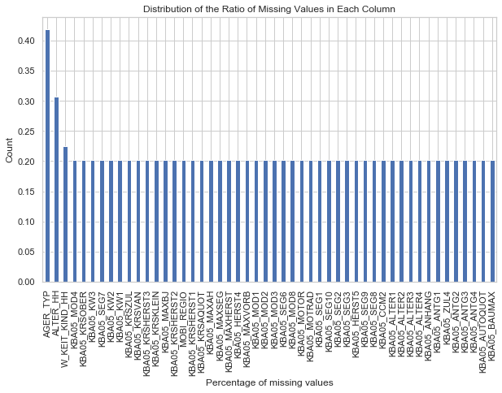

```
Columns dropped due to missing values: 2 ['AGER_TYP', 'ALTER_HH']

2.3) Drop highly correlated columns (corr > 90%)
```

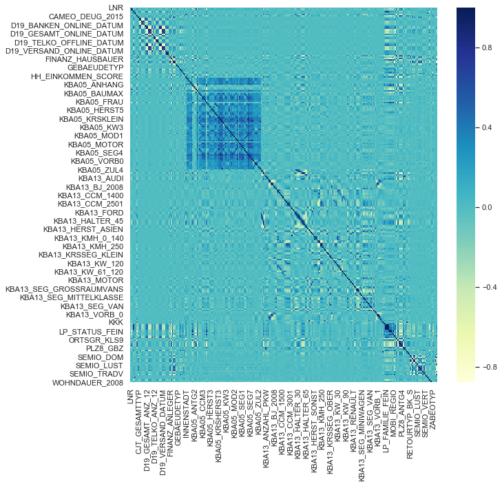

```
Columns dropped due to high correlation: 14 ['D19_GESAMT_ANZ_24', 'D19_VERSAND_ANZ_12', 'D19_VERSAND_ANZ_24', 'D19_VERSAND_OFFLINE_DATUM', 'D19_VERSAND_ONLINE_DATUM', 'D19_VERSAND_ONLINE_QUOTE_12', 'KBA05_KRSHERST3', 'KBA13_HALTER_66', 'KBA13_HERST_SONST', 'KBA13_KMH_250', 'LP_FAMILIE_GROB', 'LP_LEB…
TEST SET - Rows cannot be dropped.

Extra column(s) dropped: ['FINANZ_SPARER', 'KBA05_KRSHERST2', 'KBA05_SEG9', 'D19_VERSAND_DATUM', 'GEBAEUDETYP', 'TITEL_KZ']
Total 115 columns dropped
```

```python
# Cleaning
mailout_train = data_cleaning(mailout_train, col_to_keep = ['LNR', 'RESPONSE'], test_set = True)
```

```python
# Transforming variables
mailout_train = transform_categorical_mixed(mailout_train)
display(mailout_train.info())
```

```
7 ['ANZ_HAUSHALTE_AKTIV', 'ANZ_HH_TITEL', 'ANZ_PERSONEN', 'ANZ_TITEL', 'GEBURTSJAHR', 'KBA13_ANZAHL_PKW', 'MIN_GEBAEUDEJAHR']
19 ['FINANZ_VORSORGER', 'FINANZ_UNAUFFAELLIGER', 'FINANZTYP', 'PLZ8_BAUMAX', 'FINANZ_MINIMALIST', 'D19_KONSUMTYP', 'SHOPPER_TYP', 'HEALTH_TYP', 'VERS_TYP', 'RETOURTYP_BK_S', 'KBA05_BAUMAX', 'ZABEOTYP', 'OST_WEST_KZ', 'CAMEO_DEUG_2015', 'FINANZ_ANLEGER', 'REGIOTYP', 'FINANZ_HAUSBAUER', 'LP_FAMILIE_FE…
226 ['KBA05_ALTER4', 'KBA05_FRAU', 'KBA13_FORD', 'KBA05_HERST3', 'KBA05_MAXSEG', 'KBA05_CCM1', 'KBA05_HERST5', 'KBA13_KRSHERST_AUDI_VW', 'KBA13_KRSSEG_VAN', 'KBA13_MAZDA', 'CJT_GESAMTTYP', 'KBA13_AUTOQUOTE', 'KKK', 'KBA13_KW_70', 'KBA13_CCM_1000', 'KBA13_KMH_140_210', 'KBA13_KRSZUL_NEU', 'KBA13_BJ_2…
Transform mixed-type PRAEGENDE_JUGENDJAHRE to two categorical variables
<class 'pandas.core.frame.DataFrame'>
RangeIndex: 42962 entries, 0 to 42961
Columns: 253 entries, LNR to MOVEMENT
dtypes: float64(206), int64(45), int8(2)
memory usage: 82.4 MB
```

```
None
```

```python
display(list(set(azdias.columns) - set(mailout_train.columns)))
display(list(set(mailout_train.columns) - set(azdias.columns)))
```

```
['D19_VERSAND_OFFLINE_DATUM']
```

```
['RESPONSE', 'LNR']
```

```python
# Impute and scale each column
## Initiate imputer and scaler object
imputer = SimpleImputer(missing_values = np.nan, strategy = 'most_frequent')
scaler = StandardScaler()

## Set index and prevent RESPONSE column from imputing and scaling
mailout_train.set_index('LNR', inplace = True)
scaling_col = list(set(mailout_train.columns) - set(['RESPONSE']))
## Impute and scale the dataset and save into dataframe
mailout_train[scaling_col] = imputer.fit_transform(mailout_train[scaling_col])
mailout_train[scaling_col] = scaler.fit_transform(mailout_train[scaling_col])
train_imputed_scaled = pd.DataFrame(mailout_train,
                                    index = mailout_train.index.tolist(),
                                    columns = mailout_train.columns.tolist())

## Check few samples
display(train_imputed_scaled.head())
```

|  | ANZ_HAUSHALTE_AKTIV | ANZ_HH_TITEL | ANZ_PERSONEN | ANZ_TITEL | BALLRAUM | CAMEO_DEU_2015 | CAMEO_DEUG_2015 | CJT_GESAMTTYP | D19_BANKEN_ANZ_12 | D19_BANKEN_ANZ_24 | D19_BANKEN_DATUM | D19_BANKEN_OFFLINE_DATUM | D19_BANKEN_ONLINE_DATUM | D19_BANKEN_ONLINE_QUOTE_12 | D19_GESAMT_ANZ_12 | D19_GESAMT_DATUM | D19_GESAMT_OFFLINE_DATUM | D19_GESAMT_ONLINE_DATUM | D19_GESAMT_ONLINE_QUOTE_12 | D19_KONSUMTYP | D19_TELKO_ANZ_12 | D19_TELKO_ANZ_24 | D19_TELKO_DATUM | D19_TELKO_OFFLINE_DATUM | D19_TELKO_ONLINE_DATUM | D19_VERSI_ANZ_12 | D19_VERSI_ANZ_24 | EWDICHTE | FINANZ_ANLEGER | … |
| --- | --- | --- | --- | --- | --- | --- | --- | --- | --- | --- | --- | --- | --- | --- | --- | --- | --- | --- | --- | --- | --- | --- | --- | --- | --- | --- | --- | --- | --- | --- |
| 1763 | 0.671637 | -0.116979 | -0.656284 | -0.083831 | 0.203551 | 0.300525 | -0.069784 | -0.732206 | -0.224018 | -0.278206 | 0.397011 | 0.180465 | 0.309102 | -0.194774 | -0.670418 | 0.773572 | 0.332665 | 0.475035 | -0.589583 | -0.227393 | -0.196130 | -0.261030 | 0.400777 | 0.246638 | 0.084154 | -0.267718 | -0.336634 | 0.454064 | -0.240815 | … |
| 1771 | -0.336522 | -0.116979 | 0.113910 | -0.083831 | 0.203551 | 0.155776 | -0.069784 | -0.732206 | 1.978334 | 1.301947 | -2.670023 | 0.180465 | 0.309102 | -0.194774 | 0.732700 | -1.749834 | -3.156901 | 0.144368 | -0.589583 | -1.021027 | 3.465818 | 2.450371 | -6.349098 | -9.668591 | 0.084154 | -0.267718 | -0.336634 | -1.784637 | -0.240815 | … |
| 1776 | -0.408533 | -0.116979 | -1.426478 | -0.083831 | -1.704266 | -0.640348 | -1.419864 | 0.397980 | -0.224018 | 1.301947 | -1.443209 | 0.180465 | -1.897182 | -0.194774 | -0.670418 | -0.172705 | -0.975922 | -0.186300 | -0.589583 | -0.624210 | -0.196130 | -0.261030 | 0.400777 | 0.246638 | 0.084154 | -0.267718 | -0.336634 | 1.013739 | -0.888123 | … |
| 1460 | -0.120488 | -0.116979 | 0.113910 | -0.083831 | -1.227312 | -0.640348 | -1.419864 | -0.732206 | -0.224018 | -0.278206 | 0.397011 | 0.180465 | 0.309102 | -0.194774 | -0.670418 | 1.088998 | 0.768861 | 0.805703 | -0.589583 | -0.227393 | -0.196130 | -0.261030 | 0.400777 | 0.246638 | 0.084154 | -0.267718 | -0.336634 | 1.013739 | -0.888123 | … |
| 1783 | 3.408069 | -0.116979 | -0.656284 | -0.083831 | -0.273403 | 1.024274 | 0.830269 | 1.528167 | -0.224018 | -0.278206 | 0.397011 | 0.180465 | 0.309102 | -0.194774 | -0.670418 | 0.142721 | -0.539727 | 0.805703 | -0.589583 | -0.624210 | -0.196130 | -0.261030 | 0.400777 | 0.246638 | 0.084154 | -0.267718 | -0.336634 | 0.454064 | -0.888123 | … |

```python
# Split the dataset into training and test set
# X_train, X_test, y_train, y_test = train_test_split(train_imputed_scaled[scaling_col],
#                                                     train_imputed_scaled.RESPONSE,
#                                                     test_size = 0.2,
#                                                     random_state = 42)

# print(X_train.shape, X_test.shape, y_train.shape, y_test.shape)

X_train = train_imputed_scaled[scaling_col]
y_train = train_imputed_scaled.RESPONSE
print(X_train.shape, y_train.shape)
```

```
(42962, 251) (42962,)
```

```python
import time
# Define fit_classifier function to fit different classifiers on training dataset i.e. train_features_scaled
# to find the best performing classifier algorithm
def fit_classifier(clf, param_grid, X = X_train, y = y_train):
    ''' Fit a classifier to the training data using GridSearchCV and calculate AUC
    args:
    clf; (object) classifier to fit
    param_grid; (dict) classifier parameters used with GridSearchCV
    X_train; (dataframe) training dataset
    y_train; (dataframe) training output

    return:
    grid.best_score_; (float) best score of the model
    grid.best_estimator_; (object..?)
    time_taken; (float) time taken to run the GridSearchCV for the given classifier
    '''

    # scoring roc_auc available as parameter
    start = time.time()
    model = GridSearchCV(estimator = clf, param_grid = param_grid,
                         scoring = 'roc_auc', cv = 5, verbose = 0, n_jobs = -1)
    model.fit(X, y)
    end = time.time()
    time_taken = round(end - start, 2)

    print(clf.__class__.__name__)
    print("Time taken : {} secs".format(time_taken))
    print("Best score : {}".format(round(model.best_score_, 4)))
    print("*" * 40)

    return model.best_score_, model.best_estimator_, time_taken
```

```python
lor = LogisticRegression(random_state = 42)
rfc = RandomForestClassifier(random_state = 42)
abc = AdaBoostClassifier(random_state = 42)
gbc = GradientBoostingClassifier(random_state = 42)
xgbc = XGBClassifier(random_state = 42)
lgbmc = lgb.LGBMClassifier(random_state = 42)
```

```python
# Find best classification algorithm
clf_names = []
clf_scores = []
clf_best_ests = []
clf_time_taken = []

for clf in [lor, rfc, abc, gbc, xgbc, lgbmc]:
    best_score, best_est, time_taken = fit_classifier(clf, {}) # , param_grid[key]
    clf_names.append(clf.__class__.__name__)
    clf_scores.append(best_score)
    clf_best_ests.append(best_est)
    clf_time_taken.append(time_taken)
```

```
LogisticRegression
Time taken : 13.13 secs
Best score : 0.6127
RandomForestClassifier
Time taken : 4.29 secs
Best score : 0.5157
AdaBoostClassifier
Time taken : 19.43 secs
Best score : 0.5922
GradientBoostingClassifier
Time taken : 52.58 secs
Best score : 0.6077
XGBClassifier
Time taken : 30.36 secs
Best score : 0.6223
LGBMClassifier
Time taken : 7.33 secs
Best score : 0.5741
```

```python
clf_dict = {'best_score': clf_scores,
            'time_taken': clf_time_taken,
            'best_est': clf_best_ests}
clf_df = pd.DataFrame(clf_dict, index = clf_names)

display(clf_df.loc['GradientBoostingClassifier', 'best_score'])
display(clf_df.loc['GradientBoostingClassifier', 'best_est'])
display(clf_df.loc['XGBClassifier', 'best_score'])
display(clf_df.loc['XGBClassifier', 'best_est'])
```

```
0.6076632611478697
```

```
GradientBoostingClassifier(criterion='friedman_mse', init=None,
                           learning_rate=0.1, loss='deviance', max_depth=3,
                           max_features=None, max_leaf_nodes=None,
                           min_impurity_decrease=0.0, min_impurity_split=None,
                           min_samples_leaf=1, min_samples_split=2,
                           min_weight_fraction_leaf=0.0, n_estimators=100,
                           n_iter_no_change=None, presort='auto',
                           random_state=42, subsample=1.0, tol=0.0001,
                           validation_fraction=0.1, verbose=0,
                           warm_start=False)
```

```
0.6223263299002882
```

```
XGBClassifier(base_score=0.5, booster='gbtree', colsample_bylevel=1,
              colsample_bynode=1, colsample_bytree=1, gamma=0, gpu_id=-1,
              learning_rate=0.1, max_delta_step=0, max_depth=3,
              min_child_weight=1, missing=None, n_estimators=100, n_jobs=1,
              objective='binary:logistic', random_state=42, reg_alpha=0,
              reg_lambda=1, scale_pos_weight=1, subsample=1, tree_method='auto',
              verbosity=1)
```

```python
# Imbalance weights
weight_neg = np.sum(y_train == 0) / len(y_train)
weight_pos = np.sum(y_train == 1) / len(y_train)
weight = weight_neg / weight_pos
print(len(y_train), weight)

# Target parameters
hyperparameter_space = {'max_depth': (2, 8),
                        'n_estimators' : (100, 500),
                        'learning_rate': (0.01, 0.3),
                        # 'reg_alpha': (0, 20),
                        # 'min_child_weight': (1, 20),
                        'colsample_bytree': (0.1, 1),
                        'gamma' : (0, 10),
                        'subsample': (0.5, 1.0),
                        'scale_pos_weight': (1, weight)}

# Transform X_train to DMatrix for faster results (not necessary)
dtrain = xgb.DMatrix(X_train, label = y_train)

# optimization function
def xgbc_cv(max_depth, n_estimators, learning_rate, colsample_bytree, gamma, subsample, scale_pos_weight):
    ''' Find the optimal parameters with AUC as an evaluation metric
    args:
    max_depth, n_estimators, learning_rate,
        min_samples_leaf, min_samples_split, subsample; (float) parameters to initialize the model

    return:
    cv_result['test-auc-mean'].iloc[-1]; (float) AUC value from the trained model
    '''

    params = {'max_depth': int(max_depth),
              'n_estimators' : int(n_estimators),
              'learning_rate': learning_rate,
              # 'reg_alpha': (0, 20),
              # 'min_child_weight': (1, 20),
              'colsample_bytree': colsample_bytree,
              'gamma' : gamma,
              'subsample': subsample,
              'scale_pos_weight': scale_pos_weight,
              'eval_metric': 'auc'}

    cv_result = xgb.cv(params, dtrain, num_boost_round = 100, nfold = 5)

    return cv_result['test-auc-mean'].iloc[-1]

xgbcBO = BayesianOptimization(f = xgbc_cv, pbounds = hyperparameter_space, verbose = 10)

# alpha: a parameter for the gaussian process. This itself is a hyperparemter that can be optimized.
#        The known noise level is configured with the alpha parameter.
gp_params = {"alpha": 1e-10}

# Call .maximize method of the optimizer with the appropriate arguments
# The algorithm will randomly choose 3 points to establish a 'prior',
# then will perform 10 interations to maximize the value of estimator function
# kappa: a measure of 'aggressiveness' of the bayesian optimization process
xgbcBO.maximize(init_points = 3, n_iter = 15, acq = 'ucb', kappa = 3, **gp_params)
xgbc_params = xgbcBO.max['params']
print(xgbc_params)
```

```
42962 79.75563909774436
|   iter    |  target   | colsam... |   gamma   | learni... | max_depth | n_esti... | scale_... | subsample |
-------------------------------------------------------------------------------------------------------------
|  1        |  0.5826   |  0.6716   |  8.941    |  0.1911   |  3.212    |  423.4    |  70.01    |  0.9006   |
|  2        |  0.6075   |  0.2407   |  3.864    |  0.05484  |  4.216    |  206.5    |  66.76    |  0.7132   |
|  3        |  0.5677   |  0.5203   |  4.199    |  0.2227   |  5.03     |  451.9    |  11.52    |  0.7868   |
|  4        |  0.5581   |  0.9535   |  8.855    |  0.1456   |  5.342    |  101.9    |  79.09    |  0.8213   |
|  5        |  0.5      |  0.1      |  10.0     |  0.3      |  2.0      |  203.0    |  1.0      |  1.0      |
|  6        |  0.557    |  0.1      |  0.0      |  0.01     |  8.0      |  500.0    |  79.76    |  0.5      |
|  7        |  0.5136   |  0.9964   |  0.0      |  0.3      |  8.0      |  313.5    |  79.76    |  0.956    |
|  8        |  0.5      |  1.0      |  10.0     |  0.01     |  2.0      |  500.0    |  1.0      |  1.0      |
|  9        |  0.575    |  0.1      |  0.0      |  0.01     |  8.0      |  100.0    |  1.0      |  0.5      |
|  10       |  0.5128   |  0.1      |  0.0      |  0.3      |  8.0      |  158.3    |  79.76    |  0.5      |
|  11       |  0.5      |  0.1      |  10.0     |  0.01     |  2.0      |  344.6    |  1.0      |  0.5      |
|  12       |  0.5839   |  0.1      |  10.0     |  0.3      |  2.0      |  244.1    |  79.76    |  0.5018   |
|  13       |  0.6233   |  1.0      |  10.0     |  0.01     |  2.0      |  100.0    |  32.3     |  1.0      |
|  14       |  0.5826   |  0.1      |  0.0      |  0.3      |  2.0      |  259.0    |  41.48    |  0.5      |
|  15       |  0.6002   |  1.0      |  10.0     |  0.01     |  8.0      |  234.9    |  42.91    |  0.5      |
|  16       |  0.5893   |  0.9863   |  0.07349  |  0.2121   |  2.862    |  397.9    |  40.15    |  0.6189   |
|  17       |  0.5981   |  0.9523   |  0.8587   |  0.2704   |  2.421    |  100.3    |  45.33    |  0.8681   |
|  18       |  0.6265   |  1.0      |  0.0      |  0.01     |  2.0      |  443.4    |  79.76    |  0.5      |
=============================================================================================================
{'colsample_bytree': 0.9999999817723635, 'gamma': 0.0, 'learning_rate': 0.01, 'max_depth': 2.0, 'n_estimators': 443.43573443532335, 'scale_pos_weight': 79.75563909774436, 'subsample': 0.5}
```

```python
# Initialize bayesian optimization with hyperparameter tuning space
hyperparameter_space = {'max_depth': (2, 8),
                        'n_estimators' : (100, 500),
                        'learning_rate': (0.01, 0.3),
                        'min_samples_leaf': (0.1, 0.5), # (2, 200)
                        'min_samples_split': (0.1, 0.5),
                        # 'max_features': ["log2", "sqrt"],
                        'subsample': (0.5, 1.0)} # (2, 200)

def gbc_cv(max_depth, n_estimators, learning_rate, min_samples_leaf, min_samples_split, subsample): # max_features
    ''' Find the optimal parameters with AUC as an evaluation metric
    args:
    max_depth, n_estimators, learning_rate,
        min_samples_leaf, min_samples_split, subsample; (float) parameters to initialize the model

    return:
    y_val_auc; (float) AUC value from the trained model
    '''

    clf = GradientBoostingClassifier(max_depth = int(max_depth),
                                     n_estimators = int(n_estimators),
                                     learning_rate = learning_rate,
                                     min_samples_leaf = min_samples_leaf,
                                     min_samples_split = min_samples_split,
                                     # max_features = max_features,
                                     subsample = subsample,
                                     random_state = 42)
    model = GridSearchCV(estimator = clf, param_grid = {}, scoring = 'roc_auc', cv = 5) # , n_jobs = -1
    # Fit the training set
    model.fit(X_train, y_train)
    # Get auc value
    cv_result = round(model.best_score_, 4)
    # score = cross_val_score(model, X_train, y_train, cv = 5).mean()

    return cv_result

gbcBO = BayesianOptimization(f = gbc_cv, pbounds = hyperparameter_space, verbose = 10)

# alpha: a parameter for the gaussian process. This itself is a hyperparemter that can be optimized.
#        The known noise level is configured with the alpha parameter.
gp_params = {"alpha": 1e-10}

# Call .maximize method of the optimizer with the appropriate arguments
# The algorithm will randomly choose 3 points to establish a 'prior',
# then will perform 10 interations to maximize the value of estimator function
# kappa: a measure of 'aggressiveness' of the bayesian optimization process
gbcBO.maximize(init_points = 3, n_iter = 15, acq = 'ucb', kappa = 3, **gp_params)
gbc_params = gbcBO.max['params']
print(gbc_params)
```

```
|   iter    |  target   | learni... | max_depth | min_sa... | min_sa... | n_esti... | subsample |
-------------------------------------------------------------------------------------------------
|  1        |  0.5      |  0.2523   |  6.684    |  0.4593   |  0.3293   |  417.7    |  0.582    |
|  2        |  0.5666   |  0.1076   |  7.265    |  0.2066   |  0.3886   |  316.4    |  0.607    |
|  3        |  0.5452   |  0.03966  |  6.395    |  0.3593   |  0.1638   |  451.3    |  0.7843   |
|  4        |  0.5      |  0.3      |  2.0      |  0.5      |  0.1      |  100.0    |  1.0      |
|  5        |  0.5      |  0.3      |  2.0      |  0.5      |  0.5      |  203.3    |  0.5      |
|  6        |  0.5      |  0.3      |  2.0      |  0.5      |  0.5      |  500.0    |  0.5      |
|  7        |  0.6272   |  0.01     |  8.0      |  0.1      |  0.1      |  263.5    |  1.0      |
|  8        |  0.5      |  0.3      |  2.0      |  0.5      |  0.1      |  276.1    |  1.0      |
|  9        |  0.6271   |  0.01     |  8.0      |  0.1      |  0.1      |  146.8    |  1.0      |
|  10       |  0.6281   |  0.01     |  8.0      |  0.1      |  0.1      |  233.4    |  1.0      |
|  11       |  0.6229   |  0.01     |  8.0      |  0.1137   |  0.1      |  176.8    |  0.697    |
|  12       |  0.5      |  0.1096   |  7.999    |  0.4476   |  0.4756   |  119.3    |  0.5599   |
|  13       |  0.6263   |  0.01     |  8.0      |  0.1      |  0.1      |  361.9    |  1.0      |
|  14       |  0.6264   |  0.01     |  2.0      |  0.1      |  0.1      |  157.3    |  0.5      |
|  15       |  0.6285   |  0.01     |  2.0      |  0.1      |  0.1      |  350.4    |  0.5      |
|  16       |  0.5718   |  0.01     |  2.0      |  0.1      |  0.5      |  378.3    |  0.5      |
|  17       |  0.5      |  0.3      |  8.0      |  0.5      |  0.5      |  342.5    |  0.5      |
|  18       |  0.6258   |  0.01     |  8.0      |  0.1      |  0.1      |  479.4    |  1.0      |
=================================================================================================
{'learning_rate': 0.01, 'max_depth': 2.0, 'min_samples_leaf': 0.1, 'min_samples_split': 0.1, 'n_estimators': 350.3847531627732, 'subsample': 0.5}
```

```python
%%time

# Imbalance weights
weight_neg = np.sum(y_train == 0) / len(y_train)
weight_pos = np.sum(y_train == 1) / len(y_train)
weight = weight_neg / weight_pos
print(len(y_train), weight)

# Target parameters
hyperparameter_space = {'max_depth': (2, 8),
                        'n_estimators' : (100, 500),
                        'learning_rate': (0.01, 0.3),
                        'class_weight': (1, weight),
                        'colsample_bytree': (0.1, 1),
                        'subsample': (0.5, 1.0)}

# Transform X_train to DMatrix for faster results (not necessary)
dtrain = lgb.Dataset(X_train, label = y_train)

# optimization function
def lgbmc_cv(max_depth, n_estimators, learning_rate, class_weight, colsample_bytree, subsample):
    ''' Find the optimal parameters with AUC as an evaluation metric
    args:
    max_depth, n_estimators, learning_rate,
        class_weight, colsample_bytree, subsample; (float) parameters to initialize the model

    return:
    cv_result['test-auc-mean'].iloc[-1]; (float) AUC value from the trained model
    '''

    params = {'max_depth': int(max_depth),
              'n_estimators' : int(n_estimators),
              'learning_rate': learning_rate,
              'colsample_bytree': colsample_bytree,
              'subsample': subsample,
              'class_weight': class_weight,
              'metric': 'auc'}

    cv_result = lgb.cv(params, dtrain, num_boost_round = 100, nfold = 5)
    # print(cv_result)

    return max(cv_result['auc-mean']) # or mean...?

lgbmcBO = BayesianOptimization(f = lgbmc_cv, pbounds = hyperparameter_space, verbose = 10)

# alpha: a parameter for the gaussian process. This itself is a hyperparemter that can be optimized.
#        The known noise level is configured with the alpha parameter.
gp_params = {"alpha": 1e-10}

# Call .maximize method of the optimizer with the appropriate arguments
# The algorithm will randomly choose 3 points to establish a 'prior',
# then will perform 10 interations to maximize the value of estimator function
# kappa: a measure of 'aggressiveness' of the bayesian optimization process
lgbmcBO.maximize(init_points = 3, n_iter = 15, acq = 'ucb', kappa = 3, **gp_params)
lgbmc_params = lgbmcBO.max['params']
print(lgbmc_params)
```

```
42962 79.75563909774436
|   iter    |  target   | class_... | colsam... | learni... | max_depth | n_esti... | subsample |
-------------------------------------------------------------------------------------------------
|  1        |  0.6149   |  44.66    |  0.3514   |  0.08565  |  5.547    |  116.1    |  0.8847   |
|  2        |  0.6178   |  70.52    |  0.421    |  0.1505   |  7.281    |  474.1    |  0.8187   |
|  3        |  0.6042   |  62.2     |  0.8476   |  0.1212   |  5.956    |  234.1    |  0.6856   |
|  4        |  0.6135   |  1.039    |  0.6373   |  0.2884   |  3.049    |  496.7    |  0.8238   |
|  5        |  0.6141   |  78.33    |  0.2236   |  0.2503   |  2.611    |  100.2    |  0.8135   |
|  6        |  0.6167   |  79.15    |  0.1315   |  0.02391  |  2.274    |  498.3    |  0.8422   |
|  7        |  0.5952   |  1.579    |  0.7483   |  0.229    |  7.664    |  100.2    |  0.6704   |
|  8        |  0.6137   |  1.193    |  0.3931   |  0.2403   |  2.138    |  374.4    |  0.9899   |
|  9        |  0.6221   |  78.61    |  0.8453   |  0.2455   |  2.049    |  399.5    |  0.8026   |
|  10       |  0.6171   |  42.3     |  0.1376   |  0.07573  |  2.013    |  440.9    |  0.9711   |
|  11       |  0.6255   |  1.153    |  0.819    |  0.05399  |  2.145    |  186.6    |  0.8783   |
|  12       |  0.6235   |  79.37    |  0.6074   |  0.07414  |  2.047    |  156.4    |  0.927    |
|  13       |  0.6038   |  2.002    |  0.9769   |  0.154    |  7.991    |  183.2    |  0.9295   |
|  14       |  0.6183   |  2.232    |  0.1696   |  0.2686   |  2.038    |  282.8    |  0.928    |
|  15       |  0.6271   |  34.41    |  0.9746   |  0.07407  |  2.072    |  159.8    |  0.5188   |
|  16       |  0.6171   |  79.24    |  0.1131   |  0.06718  |  2.046    |  319.2    |  0.7786   |
|  17       |  0.6198   |  6.556    |  0.1264   |  0.08825  |  2.058    |  143.7    |  0.9889   |
|  18       |  0.6139   |  79.2     |  0.1392   |  0.1962   |  2.096    |  454.9    |  0.515    |
=================================================================================================
{'class_weight': 34.408105441135, 'colsample_bytree': 0.9746227887139718, 'learning_rate': 0.07406503798273137, 'max_depth': 2.0720255200228035, 'n_estimators': 159.75828359758214, 'subsample': 0.5187826501983863}
CPU times: user 13min 56s, sys: 17.6 s, total: 14min 14s
Wall time: 2min 29s
```

```python
# Refit the gradient boosting
gbc_opt = GradientBoostingClassifier(max_depth = int(gbc_params['max_depth']),
                                     n_estimators = int(gbc_params['n_estimators']),
                                     learning_rate = gbc_params['learning_rate'],
                                     min_samples_leaf = gbc_params['min_samples_leaf'], # int(),
                                     min_samples_split = gbc_params['min_samples_split'], # int(),
                                     subsample = gbc_params['subsample'],
                                     random_state = 42)

gbc_opt.fit(train_imputed_scaled[scaling_col], train_imputed_scaled.RESPONSE) # (X_train, y_train)

# save the model to disk
filename = 'GBC_model_20200215.sav'
pickle.dump(gbc_opt, open(filename, 'wb'))
```

```python
# Refit the xgboost with the optimized parameters
xgbc_opt = xgb.XGBClassifier(booster = 'gbtree',
                             max_depth = int(xgbc_params['max_depth']),
                             n_estimators = int(xgbc_params['n_estimators']),
                             learning_rate = xgbc_params['learning_rate'],
                             # reg_alpha = xgbc_params['reg_alpha'], # For L1 regularization (default = 0)
                             # min_child_weight = xgbc_params['min_child_weight'],
                             colsample_bytree = xgbc_params['colsample_bytree'],
                             gamma = xgbc_params['gamma'],
                             subsample = xgbc_params['subsample'],
                             # thread = -1,
                             # eval_metric = 'auc',
                             objective = 'binary:logistic',
                             scale_pos_weight = xgbc_params['scale_pos_weight'],
                             seed = 42)

xgbc_opt.fit(train_imputed_scaled[scaling_col], train_imputed_scaled.RESPONSE) # (X_train, y_train)

# save the model to disk
filename = 'XGBC_Model_20200215.sav'
pickle.dump(xgbc_opt, open(filename, 'wb'))
```

```python
features_importance = pd.DataFrame({'value': xgbc_opt.feature_importances_},
                                   index = X_train.columns)
features_importance.sort_values(by = 'value', ascending = False, inplace = True)
display(features_importance.head(10))

# ax = xgb.plot_importance(xgbc_opt)
# fig = ax.figure
# fig.set_size_inches(16, 10)
# plt.title('XGBoost Feature Importance, Training Set')
# plt.show()
```

|  | value |
| --- | --- |
| D19_KONSUMTYP | 0.009413 |
| KBA13_SEG_OBERKLASSE | 0.008179 |
| HH_EINKOMMEN_SCORE | 0.007019 |
| KBA13_SEG_MITTELKLASSE | 0.006887 |
| D19_BANKEN_ANZ_24 | 0.006457 |
| KBA05_MAXHERST | 0.006452 |
| KBA13_SEG_KLEINST | 0.006431 |
| KBA13_FAB_ASIEN | 0.006379 |
| KBA05_KW3 | 0.006327 |
| KBA13_BJ_2000 | 0.006192 |

```python
# Refit the LightBGM with the optimized parameters
lgbmc_opt = lgb.LGBMClassifier(max_depth = int(lgbmc_params['max_depth']),
                               n_estimators = int(lgbmc_params['n_estimators']),
                               learning_rate = lgbmc_params['learning_rate'],
                               scale_pos_weight = lgbmc_params['class_weight'], # class_weight only accepts dictionary
                               colsample_bytree = lgbmc_params['colsample_bytree'],
                               subsample = lgbmc_params['subsample'],
                               # eval_metric = 'auc',
                               random_state = 42)

lgbmc_opt.fit(train_imputed_scaled[scaling_col], train_imputed_scaled.RESPONSE) # (X_train, y_train)

# save the model to disk
filename = 'LGBMC_model_20200215.sav'
pickle.dump(lgbmc_opt, open(filename, 'wb'))
```

## Part 3: Kaggle Competition

Now that you've created a model to predict which individuals are most likely to respond to a mailout campaign, it's time to test that model in competition through Kaggle. If you click on the link [here](http://www.kaggle.com/t/21e6d45d4c574c7fa2d868f0e8c83140), you'll be taken to the competition page where, if you have a Kaggle account, you can enter. If you're one of the top performers, you may have the chance to be contacted by a hiring manager from Arvato or Bertelsmann for an interview!

Your entry to the competition should be a CSV file with two columns. The first column should be a copy of "LNR", which acts as an ID number for each individual in the "TEST" partition. The second column, "RESPONSE", should be some measure of how likely each individual became a customer – this might not be a straightforward probability. As you should have found in Part 2, there is a large output class imbalance, where most individuals did not respond to the mailout. Thus, predicting individual classes and using accuracy does not seem to be an appropriate performance evaluation method. Instead, the competition will be using AUC to evaluate performance. The exact values of the "RESPONSE" column do not matter as much: only that the higher values try to capture as many of the actual customers as possible, early in the ROC curve sweep.

### Part 3 Results

In this part, I used the `Gradient Boosting` model, which showed the best performance in the previous section, to predict which individuals are most likely to respond to a mailout campaign. With the training set, the AUC score of this model was 0.6285. And my Kaggle score was 0.65388. Given that the data was highly imbalanced, I believe the model's performance is fine.

In addition to the `Gradient Boosting` model, `XGBoost` model also showed similar performance (AUC = 0.65095). These results indicate that models based on gradient boosting algorithm are very good fit for this problem given that we are dealing with a very large dataset for a classification problem.

### Reflection

This was my first time working on a real-life dataset, and it has been a great learning experience on how to approach the problem in a methodical approach. The most challenging part for me was mainly on getting the data cleansed and processed without losing the key information.

In the Customer Segmentation part, I have performed data pre-processing and used the PCA method combined with the K-Means Clustering algorithm to get the clusters within the general population and customers. The clusters obtained were compared, and I was able to observe the differences in the clusters allocation. By digging into these differences, I was able to figure out which segment of the general population would be the biggest customer segment for mail-order company and vice versa. With the understanding of this difference, a company could focus more on the biggest customer segment within the general population and then perform target mail-out campaign. This would increase the customer conversion rate while reducing marketing costs.

In the supervised learning part, I was able to predict the class probabilities of each individual in the testing set to become a customer. To deal with the large and imbalanced dataset, I tried several algorithms and found out that gradient boosting algorithms outperforms other algorithms. In the Kaggle competition, I achieved an AUC score of 0.65388.

### Improvement

For simplicity, I kept the categorical- and ordinal-type variables as given in the original dataset. The underlying assumption is that these variables are representing the actual scale of difference. However, this may not be the case, and properly transforming these variables would help to improve the model.

Additionally, feature engineering (e.g., using Featuretools, an open-source Python library for automated feature engineering) and fine-tuning the model would also help to improve the prediction performance.

```python
# ../../data/Term2/capstone/arvato_data/
mailout_test = pd.read_csv(path + 'Udacity_MAILOUT_052018_TEST.csv', sep = ';', low_memory = False)
```

```python
display(mailout_test.shape)
display(mailout_test.info())
display(mailout_test.head())
# display(mailout_test.RESPONSE.value_counts())
```

```
(42833, 366)
```

```
<class 'pandas.core.frame.DataFrame'>
RangeIndex: 42833 entries, 0 to 42832
Columns: 366 entries, LNR to ALTERSKATEGORIE_GROB
dtypes: float64(267), int64(93), object(6)
memory usage: 119.6+ MB
```

```
None
```

|  | LNR | AGER_TYP | AKT_DAT_KL | ALTER_HH | ALTER_KIND1 | ALTER_KIND2 | ALTER_KIND3 | ALTER_KIND4 | ALTERSKATEGORIE_FEIN | ANZ_HAUSHALTE_AKTIV | ANZ_HH_TITEL | ANZ_KINDER | ANZ_PERSONEN | ANZ_STATISTISCHE_HAUSHALTE | ANZ_TITEL | ARBEIT | BALLRAUM | CAMEO_DEU_2015 | CAMEO_DEUG_2015 | CAMEO_INTL_2015 | CJT_GESAMTTYP | CJT_KATALOGNUTZER | CJT_TYP_1 | CJT_TYP_2 | CJT_TYP_3 | CJT_TYP_4 | CJT_TYP_5 | CJT_TYP_6 | D19_BANKEN_ANZ_12 | … |
| --- | --- | --- | --- | --- | --- | --- | --- | --- | --- | --- | --- | --- | --- | --- | --- | --- | --- | --- | --- | --- | --- | --- | --- | --- | --- | --- | --- | --- | --- | --- |
| 0 | 1754 | 2 | 1.0 | 7.0 | NaN | NaN | NaN | NaN | 6.0 | 2.0 | 0.0 | 0.0 | 2.0 | 2.0 | 0.0 | 3.0 | 6.0 | 2B | 2 | 13 | 5.0 | 5.0 | 1.0 | 2.0 | 5.0 | 5.0 | 5.0 | 5.0 | 0 | … |
| 1 | 1770 | -1 | 1.0 | 0.0 | NaN | NaN | NaN | NaN | 0.0 | 20.0 | 0.0 | 0.0 | 1.0 | 21.0 | 0.0 | 4.0 | 7.0 | 5A | 5 | 31 | 1.0 | 5.0 | 2.0 | 2.0 | 5.0 | 5.0 | 4.0 | 5.0 | 0 | … |
| 2 | 1465 | 2 | 9.0 | 16.0 | NaN | NaN | NaN | NaN | 11.0 | 2.0 | 0.0 | 0.0 | 4.0 | 2.0 | 0.0 | 4.0 | 1.0 | 7A | 7 | 41 | 2.0 | 5.0 | 2.0 | 2.0 | 5.0 | 5.0 | 5.0 | 5.0 | 0 | … |
| 3 | 1470 | -1 | 7.0 | 0.0 | NaN | NaN | NaN | NaN | 0.0 | 1.0 | 0.0 | 0.0 | 0.0 | 1.0 | 0.0 | 4.0 | 1.0 | 2B | 2 | 13 | 4.0 | 5.0 | 2.0 | 1.0 | 5.0 | 5.0 | 5.0 | 5.0 | 0 | … |
| 4 | 1478 | 1 | 1.0 | 21.0 | NaN | NaN | NaN | NaN | 13.0 | 1.0 | 0.0 | 0.0 | 4.0 | 1.0 | 0.0 | 3.0 | 6.0 | 5A | 5 | 31 | 6.0 | 1.0 | 3.0 | 2.0 | 4.0 | 4.0 | 4.0 | 3.0 | 3 | … |

```
1.1) Transform object to numeric-type columns
[Before transforming]
CAMEO_DEU_2015 : ['2B' '5A' '7A' '9D' '4E' '6B' '2D' '1D' '7E' '4C' nan '1C' '4A' '5F' '6D'
 '3C' '9B' '6C' '8B' '3D' '5D' '1A' '3A' '7B' '2C' '8A' '6F' '2A' '5B'
 '6E' '5C' '8D' '4D' '8C' '9E' '7C' '9A' '6A' '9C' '1B' '3B' '7D' '1E'
 'XX' '4B' '5E']
CAMEO_DEUG_2015 : ['2' '5' '7' '9' '4' '6' '1' nan '3' '8' 'X']
CAMEO_INTL_2015 : ['13' '31' '41' '51' '25' '43' '14' '15' '45' '24' nan '22' '35' '44' '34'
 '23' '12' '32' '33' '55' '54' '52' 'XX']
D19_LETZTER_KAUF_BRANCHE : ['D19_BEKLEIDUNG_GEH' 'D19_UNBEKANNT' 'D19_LEBENSMITTEL'
 'D19_BANKEN_GROSS' 'D19_SONSTIGE' 'D19_HAUS_DEKO' 'D19_VERSICHERUNGEN'
 'D19_BUCH_CD' 'D19_VERSAND_REST' 'D19_BEKLEIDUNG_REST'
 'D19_VOLLSORTIMENT' 'D19_ENERGIE' 'D19_DROGERIEARTIKEL'
 'D19_WEIN_FEINKOST' nan 'D19_TELKO_MOBILE' 'D19_HANDWERK'
 'D19_TELKO_REST' 'D19_LOTTO' 'D19_BANKEN_DIREKT' 'D19_SCHUHE'
 'D19_TECHNIK' 'D19_BILDUNG' 'D19_RATGEBER' 'D19_DIGIT_SERV'
 'D19_NAHRUNGSERGAENZUNG' 'D19_GARTEN' 'D19_BIO_OEKO' 'D19_SAMMELARTIKEL'
 'D19_FREIZEIT' 'D19_BANKEN_LOKAL' 'D19_KINDERARTIKEL' 'D19_TIERARTIKEL'
 'D19_BANKEN_REST' 'D19_REISEN' 'D19_KOSMETIK']
EINGEFUEGT_AM : ['1993-11-03 00:00:00' '1992-02-10 00:00:00' '1992-02-12 00:00:00' ...
 '2001-07-09 00:00:00' '2003-08-06 00:00:00' '2002-10-14 00:00:00']
OST_WEST_KZ : ['W' 'O' nan]

[After transforming]
CAMEO_DEU_2015 : ['2B' '5A' '7A' '9D' '4E' '6B' '2D' '1D' '7E' '4C' nan '1C' '4A' '5F' '6D'
 '3C' '9B' '6C' '8B' '3D' '5D' '1A' '3A' '7B' '2C' '8A' '6F' '2A' '5B'
 '6E' '5C' '8D' '4D' '8C' '9E' '7C' '9A' '6A' '9C' '1B' '3B' '7D' '1E'
 'XX' '4B' '5E']
CAMEO_DEUG_2015 : [ 2.  5.  7.  9.  4.  6.  1. nan  3.  8.]
CAMEO_INTL_2015 : [13. 31. 41. 51. 25. 43. 14. 15. 45. 24. nan 22. 35. 44. 34. 23. 12. 32.
 33. 55. 54. 52.]
D19_LETZTER_KAUF_BRANCHE : ['D19_BEKLEIDUNG_GEH' 'D19_UNBEKANNT' 'D19_LEBENSMITTEL'
 'D19_BANKEN_GROSS' 'D19_SONSTIGE' 'D19_HAUS_DEKO' 'D19_VERSICHERUNGEN'
 'D19_BUCH_CD' 'D19_VERSAND_REST' 'D19_BEKLEIDUNG_REST'
 'D19_VOLLSORTIMENT' 'D19_ENERGIE' 'D19_DROGERIEARTIKEL'
 'D19_WEIN_FEINKOST' nan 'D19_TELKO_MOBILE' 'D19_HANDWERK'
 'D19_TELKO_REST' 'D19_LOTTO' 'D19_BANKEN_DIREKT' 'D19_SCHUHE'
 'D19_TECHNIK' 'D19_BILDUNG' 'D19_RATGEBER' 'D19_DIGIT_SERV'
 'D19_NAHRUNGSERGAENZUNG' 'D19_GARTEN' 'D19_BIO_OEKO' 'D19_SAMMELARTIKEL'
 'D19_FREIZEIT' 'D19_BANKEN_LOKAL' 'D19_KINDERARTIKEL' 'D19_TIERARTIKEL'
 'D19_BANKEN_REST' 'D19_REISEN' 'D19_KOSMETIK']
EINGEFUEGT_AM : ['1993-11-03 00:00:00' '1992-02-10 00:00:00' '1992-02-12 00:00:00' ...
 '2001-07-09 00:00:00' '2003-08-06 00:00:00' '2002-10-14 00:00:00']
OST_WEST_KZ : ['W' 'O' nan]

1.2) Deal with unknown values

2.1) Drop columns not covered in the attribute or information dataset
Columns dropped due non coverage in the description files: 93 columns ['AKT_DAT_KL', 'ALTERSKATEGORIE_FEIN', 'ALTER_KIND1', 'ALTER_KIND2', 'ALTER_KIND3', 'ALTER_KIND4', 'ANZ_KINDER', 'ANZ_STATISTISCHE_HAUSHALTE', 'ARBEIT', 'CAMEO_INTL_2015', 'CJT_KATALOGNUTZER', 'CJT_TYP_1', 'CJT_TYP_2', 'CJT_TYP_3'…

2.2) Drop columns with missing values greater than 30% in the dataset
```

[figure not shown]

```
Columns dropped due to missing values: 2 ['AGER_TYP', 'ALTER_HH']

2.3) Drop highly correlated columns (corr > 90%)
```

[figure not shown]

```
Columns dropped due to high correlation: 14 ['D19_GESAMT_ANZ_24', 'D19_VERSAND_ANZ_12', 'D19_VERSAND_ANZ_24', 'D19_VERSAND_OFFLINE_DATUM', 'D19_VERSAND_ONLINE_DATUM', 'D19_VERSAND_ONLINE_QUOTE_12', 'KBA05_KRSHERST3', 'KBA13_HALTER_66', 'KBA13_HERST_SONST', 'KBA13_KMH_250', 'LP_FAMILIE_GROB', 'LP_LEB…
TEST SET - Rows cannot be dropped.

Extra column(s) dropped: ['FINANZ_SPARER', 'KBA05_KRSHERST2', 'KBA05_SEG9', 'D19_VERSAND_DATUM', 'GEBAEUDETYP', 'TITEL_KZ']
Total 115 columns dropped
```

```python
# Cleaning
mailout_test = data_cleaning(mailout_test, col_to_keep = ['LNR'], test_set = True)
```

```python
# Transforming variables
mailout_test = transform_categorical_mixed(mailout_test)
display(mailout_test.info())
```

```
7 ['ANZ_HAUSHALTE_AKTIV', 'ANZ_HH_TITEL', 'ANZ_PERSONEN', 'ANZ_TITEL', 'GEBURTSJAHR', 'KBA13_ANZAHL_PKW', 'MIN_GEBAEUDEJAHR']
19 ['FINANZ_VORSORGER', 'FINANZ_UNAUFFAELLIGER', 'FINANZTYP', 'PLZ8_BAUMAX', 'FINANZ_MINIMALIST', 'D19_KONSUMTYP', 'SHOPPER_TYP', 'HEALTH_TYP', 'VERS_TYP', 'RETOURTYP_BK_S', 'KBA05_BAUMAX', 'ZABEOTYP', 'OST_WEST_KZ', 'CAMEO_DEUG_2015', 'FINANZ_ANLEGER', 'REGIOTYP', 'FINANZ_HAUSBAUER', 'LP_FAMILIE_FE…
225 ['KBA05_ALTER4', 'KBA05_FRAU', 'KBA13_FORD', 'KBA05_HERST3', 'KBA05_MAXSEG', 'KBA05_CCM1', 'KBA05_HERST5', 'KBA13_KRSHERST_AUDI_VW', 'KBA13_KRSSEG_VAN', 'KBA13_MAZDA', 'CJT_GESAMTTYP', 'KBA13_AUTOQUOTE', 'KKK', 'KBA13_KW_70', 'KBA13_CCM_1000', 'KBA13_KMH_140_210', 'KBA13_KRSZUL_NEU', 'KBA13_BJ_2…
Transform mixed-type PRAEGENDE_JUGENDJAHRE to two categorical variables
<class 'pandas.core.frame.DataFrame'>
RangeIndex: 42833 entries, 0 to 42832
Columns: 252 entries, LNR to MOVEMENT
dtypes: float64(206), int64(44), int8(2)
memory usage: 81.8 MB
```

```
None
```

```python
display(list(set(mailout_train.columns) - set(mailout_test.columns)))
display(list(set(mailout_test.columns) - set(mailout_train.columns)))
```

```
['RESPONSE']
```

```
['LNR']
```

```python
## Set index and prevent RESPONSE column from imputing and scaling
mailout_test.set_index('LNR', inplace = True)
scaling_col = list(set(mailout_test.columns) - set(['RESPONSE']))
## Impute and scale the dataset and save into dataframe
mailout_test[scaling_col] = imputer.fit_transform(mailout_test[scaling_col])
mailout_test[scaling_col] = scaler.fit_transform(mailout_test[scaling_col])
test_imputed_scaled = pd.DataFrame(mailout_test,
                                   index = mailout_test.index.tolist(),
                                   columns = mailout_test.columns.tolist())

## Check few samples
display(test_imputed_scaled.head())
```

|  | ANZ_HAUSHALTE_AKTIV | ANZ_HH_TITEL | ANZ_PERSONEN | ANZ_TITEL | BALLRAUM | CAMEO_DEU_2015 | CAMEO_DEUG_2015 | CJT_GESAMTTYP | D19_BANKEN_ANZ_12 | D19_BANKEN_ANZ_24 | D19_BANKEN_DATUM | D19_BANKEN_OFFLINE_DATUM | D19_BANKEN_ONLINE_DATUM | D19_BANKEN_ONLINE_QUOTE_12 | D19_GESAMT_ANZ_12 | D19_GESAMT_DATUM | D19_GESAMT_OFFLINE_DATUM | D19_GESAMT_ONLINE_DATUM | D19_GESAMT_ONLINE_QUOTE_12 | D19_KONSUMTYP | D19_TELKO_ANZ_12 | D19_TELKO_ANZ_24 | D19_TELKO_DATUM | D19_TELKO_OFFLINE_DATUM | D19_TELKO_ONLINE_DATUM | D19_VERSI_ANZ_12 | D19_VERSI_ANZ_24 | EWDICHTE | FINANZ_ANLEGER | … |
| --- | --- | --- | --- | --- | --- | --- | --- | --- | --- | --- | --- | --- | --- | --- | --- | --- | --- | --- | --- | --- | --- | --- | --- | --- | --- | --- | --- | --- | --- | --- |
| 1754 | -0.273330 | -0.120872 | 0.108587 | -0.088595 | 0.674524 | -0.791792 | -1.419477 | 0.968505 | -0.224471 | -0.277954 | 0.400851 | 0.182923 | 0.309539 | -0.193380 | 0.028196 | -0.796480 | -0.085535 | -1.176646 | 1.864509 | -0.223671 | -0.190578 | -0.25776 | 0.401412 | 0.246932 | 0.085084 | -0.263894 | -0.333937 | 0.468930 | -0.890040 | … |
| 1770 | 1.047062 | -0.120872 | -0.660824 | -0.088595 | 1.153740 | 0.078081 | -0.069416 | -1.310239 | -0.224471 | -0.277954 | 0.400851 | 0.182923 | 0.309539 | -0.193380 | -0.675200 | 0.779590 | 0.345138 | 0.807968 | -0.593533 | -0.223671 | -0.190578 | -0.25776 | 0.401412 | 0.246932 | 0.085084 | -0.263894 | -0.333937 | -0.087907 | -0.890040 | … |
| 1465 | -0.273330 | -0.120872 | 1.647408 | -0.088595 | -1.721553 | 0.947954 | 0.830625 | -0.740553 | -0.224471 | -0.277954 | 0.400851 | 0.182923 | 0.309539 | -0.193380 | -0.675200 | 1.094804 | 0.775811 | 0.807968 | -0.593533 | 2.165682 | -0.190578 | -0.25776 | 0.401412 | 0.246932 | 0.085084 | -0.263894 | -0.333937 | -0.087907 | -0.890040 | … |
| 1470 | -0.346685 | -0.120872 | -1.430235 | -0.088595 | -1.721553 | -0.791792 | -1.419477 | 0.398819 | -0.224471 | -0.277954 | 0.400851 | 0.182923 | 0.309539 | -0.193380 | -0.675200 | 0.464376 | -0.085535 | 0.146430 | -0.593533 | 2.165682 | -0.190578 | -0.25776 | 0.401412 | 0.246932 | 0.085084 | -0.263894 | -0.333937 | -0.087907 | -0.242855 | … |
| 1478 | -0.346685 | -0.120872 | 1.647408 | -0.088595 | 0.674524 | 0.078081 | -0.069416 | 1.538191 | 6.322121 | 6.027140 | -4.431246 | -2.192797 | -5.503676 | 5.258141 | 2.138385 | -1.426908 | -2.238901 | -1.838183 | 1.127097 | -1.020122 | -0.190578 | 2.48525 | -1.869780 | -1.971595 | -3.723049 | -0.263894 | 1.402981 | -1.758421 | 0.404330 | … |

```python
display(set(X_train.columns) - set(test_imputed_scaled.columns))
display(set(test_imputed_scaled.columns) - set(X_train.columns))
```

```
set()
```

```
set()
```

```python
xgbc_test_pred = xgbc_opt.predict(test_imputed_scaled[X_train.columns])
xgbc_test_proba = xgbc_opt.predict_proba(test_imputed_scaled[X_train.columns])[:, 1]

display(xgbc_opt.classes_)
display(xgbc_test_proba)
```

```
array([0, 1])
```

```
array([0.6261727 , 0.54977846, 0.22100018, ..., 0.44613147, 0.36324316,
       0.21110226], dtype=float32)
```

```python
xgbc_kaggle_df = pd.DataFrame({'LNR': test_imputed_scaled.index.tolist(), 'RESPONSE': xgbc_test_proba})
display(xgbc_kaggle_df.head())
display(xgbc_kaggle_df.shape)
```

|  | LNR | RESPONSE |
| --- | --- | --- |
| 0 | 1754 | 0.626173 |
| 1 | 1770 | 0.549778 |
| 2 | 1465 | 0.221000 |
| 3 | 1470 | 0.178947 |
| 4 | 1478 | 0.382716 |

```
(42833, 2)
```

```python
gbc_test_pred = gbc_opt.predict(test_imputed_scaled[X_train.columns])
gbc_test_proba = gbc_opt.predict_proba(test_imputed_scaled[X_train.columns])[:, 1]

display(gbc_opt.classes_)
display(gbc_test_proba)
```

```
array([0, 1])
```

```
array([0.01770283, 0.0209549 , 0.00629304, ..., 0.01464926, 0.00681248,
       0.00514813])
```

```python
gbc_kaggle_df = pd.DataFrame({'LNR': test_imputed_scaled.index.tolist(), 'RESPONSE': gbc_test_proba})
display(gbc_kaggle_df.head())
display(gbc_kaggle_df.shape)
```

|  | LNR | RESPONSE |
| --- | --- | --- |
| 0 | 1754 | 0.017703 |
| 1 | 1770 | 0.020955 |
| 2 | 1465 | 0.006293 |
| 3 | 1470 | 0.006465 |
| 4 | 1478 | 0.010339 |

```
(42833, 2)
```

```python
lgbmc_test_pred = lgbmc_opt.predict(test_imputed_scaled[X_train.columns])
lgbmc_test_proba = lgbmc_opt.predict_proba(test_imputed_scaled[X_train.columns])[:, 1]

display(lgbmc_opt.classes_)
display(lgbmc_test_proba)
```

```
array([0, 1])
```

```
array([0.44068987, 0.36005066, 0.08302139, ..., 0.26135725, 0.25053986,
       0.05969798])
```

```python
lgbmc_kaggle_df = pd.DataFrame({'LNR': test_imputed_scaled.index.tolist(), 'RESPONSE': lgbmc_test_proba})
display(lgbmc_kaggle_df.head())
display(lgbmc_kaggle_df.shape)
```

|  | LNR | RESPONSE |
| --- | --- | --- |
| 0 | 1754 | 0.440690 |
| 1 | 1770 | 0.360051 |
| 2 | 1465 | 0.083021 |
| 3 | 1470 | 0.062939 |
| 4 | 1478 | 0.207901 |

```
(42833, 2)
```

```python
xgbc_kaggle_df.to_csv('kaggle_submission_xgbc_20200215.csv', index = False)
gbc_kaggle_df.to_csv('kaggle_submission_gbc_20200215.csv', index = False)
lgbmc_kaggle_df.to_csv('kaggle_submission_lgbmc_20200215.csv', index = False)
```

```python
from subprocess import call
call(['python', '-m', 'nbconvert', 'Arvato Project Workbook.ipynb'])
```

```
0
```

## Trials

```python
weight_neg = np.sum(y_train == 0) / len(y_train)
weight_pos = np.sum(y_train == 1) / len(y_train)
weight = weight_neg / weight_pos

param_grid = {'lor': {"C": np.linspace(0.1, 100, 7),
                      "class_weight": ["balanced", None]},
              'rfc': {"n_estimators": [100], # 10, 50,
                      "criterion": ["gini"],
                      "max_depth": [3, 5, 8],
                      "min_samples_split": np.linspace(0.1, 0.5, 7),
                      "min_samples_leaf": np.linspace(0.1, 0.5, 7),
                      "max_features": ["log2", "sqrt"],
                      "class_weight": ["balanced", None]},
              'abc': {"n_estimators": [100], # 10, 50
                      "learning_rate": [0.01, 0.05, 0.1, 0.15, 0.2]},
              'gbc': {"loss": ["deviance"],
                      "learning_rate": [0.01, 0.05, 0.1, 0.15, 0.2],
                      "min_samples_split": np.linspace(0.1, 0.5, 7),
                      "min_samples_leaf": np.linspace(0.1, 0.5, 7),
                      "max_depth": [3, 5, 8],
                      "max_features": ["log2", "sqrt"], # "criterion": ["friedman_mse", "mae"],
                      "subsample": [0.5, 0.7, 1.0],
                      "n_estimators": [100]}, # 10, 50,
              'xgbc': {"objective": ["binary:logistic"], # binary:logistic returns probability "reg:squarederror",
                       "learning_rate": [0.01, 0.05, 0.1, 0.15, 0.2],
                       "max_depth": [3, 5, 8],
                       "subsample": [0.5, 0.7, 1.0],
                       "scale_pos_weight": [weight, 1],
                       "colsample_bytree": [0.3, 0.5, 0.7, 0.8], # number of columns used by each tree
                       "gamma": [0, 1, 5, 10],
                       "n_estimators": [100], # 10, 50,
                       "eval_metric": ["auc"]},
              'lgbmc': {"max_depth": [3, 5, 8],
                        "learning_rate": [0.01, 0.05, 0.1, 0.15, 0.2],
                        "n_estimators": [100], # 10, 50,
                        "class_weight": ["balanced", None],
                        "subsample": [0.5, 0.7, 1.0],
                        "colsample_bytree": [0.3, 0.5, 0.7, 0.8]}}


# Find best classification algorithm
clf_names_gridcv = []
clf_scores_gridcv = []
clf_best_ests_gridcv = []
clf_time_taken_gridcv = []

for clf, key in zip([gbc, xgbc], list(param_grid.keys())[3:5]):
    print(key)
    best_score, best_est, time_taken = fit_classifier(clf, param_grid[key])
    clf_names_gridcv.append(clf.__class__.__name__)
    clf_scores_gridcv.append(best_score)
    clf_best_ests_gridcv.append(best_est)
    clf_time_taken_gridcv.append(time_taken)

# LogisticRegression
# Time taken : 119.27 secs
# Best score : 0.6152
# ****************************************
# RandomForestClassifier
# Time taken : 281.77 secs
# Best score : 0.5959
# ****************************************
# AdaBoostClassifier
# Time taken : 80.82 secs
# Best score : 0.6129
# ****************************************
# GradientBoostingClassifier
# Time taken : 5387.76 secs
# Best score : 0.6381
# ****************************************
# XGBClassifier
# Time taken : 12396.86 secs
# Best score : 0.6368
# ****************************************
```

```python
# Split the dataset into training and test set
X_train, X_test, y_train, y_test = train_test_split(train_imputed_scaled[scaling_col],
                                                    train_imputed_scaled.RESPONSE,
                                                    test_size = 0.2,
                                                    random_state = 42)

print(X_train.shape, X_test.shape, y_train.shape, y_test.shape)
```

```
(34369, 251) (8593, 251) (34369,) (8593,)
```

```python
def gbc_cv(max_depth, n_estimators, learning_rate, min_samples_leaf, min_samples_split, subsample): # max_features
    ''' Find the optimal parameters with AUC as an evaluation metric
    args:
    max_depth, n_estimators, learning_rate,
        min_samples_leaf, min_samples_split, subsample; (float) parameters to initialize the model

    return:
    y_val_auc; (float) AUC value from the trained model
    '''

    model = GradientBoostingClassifier(max_depth = int(max_depth),
                                       n_estimators = int(n_estimators),
                                       learning_rate = learning_rate,
                                       min_samples_leaf = min_samples_leaf,
                                       min_samples_split = min_samples_split,
                                       # max_features = max_features,
                                       subsample = subsample,
                                       random_state = 42)
    # Fit the training set
    model.fit(X_train, y_train)
    # Predict the test set
    y_score = model.predict_proba(X_test)[:, 1]
    # Get the auc of the test set
    y_val_auc = roc_auc_score(y_test, y_score) # y_score and y_test are in ndarray while y_train is in dataframe

    return y_val_auc

# Initialize bayesian optimization with hyperparameter tuning space
hyperparameter_space = {'max_depth': (2, 8),
                        'n_estimators' : (100, 500),
                        'learning_rate': (0.01, 0.3),
                        'min_samples_leaf': (0.1, 0.5), # (2, 200)
                        'min_samples_split': (0.1, 0.5),
                        # 'max_features': ["log2", "sqrt"],
                        'subsample': (0.5, 1.0)} # (2, 200)
gbcBO = BayesianOptimization(f = gbc_cv, pbounds = hyperparameter_space, verbose = 10)

# alpha: a parameter for the gaussian process. This itself is a hyperparemter that can be optimized.
#        The known noise level is configured with the alpha parameter.
gp_params = {"alpha": 1e-10}

# Call .maximize method of the optimizer with the appropriate arguments
# The algorithm will randomly choose 3 points to establish a 'prior',
# then will perform 10 interations to maximize the value of estimator function
# kappa: a measure of 'aggressiveness' of the bayesian optimization process
gbcBO.maximize(init_points = 3, n_iter = 15, acq = 'ucb', kappa = 3, **gp_params)
gbc_params = gbcBO.max['params']
print(gbc_params)
```

```
|   iter    |  target   | learni... | max_depth | min_sa... | min_sa... | n_esti... | subsample |
-------------------------------------------------------------------------------------------------
|  1        |  0.5421   |  0.1203   |  2.445    |  0.2656   |  0.4999   |  447.4    |  0.6375   |
|  2        |  0.5467   |  0.1702   |  3.037    |  0.4186   |  0.4996   |  159.9    |  0.9529   |
|  3        |  0.5353   |  0.191    |  3.593    |  0.3791   |  0.4009   |  412.3    |  0.9663   |
|  4        |  0.5374   |  0.1427   |  7.906    |  0.3333   |  0.1752   |  100.1    |  0.9479   |
|  5        |  0.5172   |  0.2696   |  7.964    |  0.3831   |  0.4595   |  500.0    |  0.8032   |
|  6        |  0.5      |  0.01     |  2.0      |  0.1      |  0.5      |  261.0    |  0.5      |
|  7        |  0.5458   |  0.2474   |  2.001    |  0.2321   |  0.2765   |  100.6    |  0.7225   |
|  8        |  0.552    |  0.1324   |  2.098    |  0.2203   |  0.1971   |  129.8    |  0.5231   |
|  9        |  0.5073   |  0.1702   |  2.08     |  0.4849   |  0.1296   |  132.0    |  0.9784   |
|  10       |  0.4966   |  0.3      |  8.0      |  0.1      |  0.1      |  335.2    |  0.5      |
|  11       |  0.5      |  0.01     |  8.0      |  0.1      |  0.5      |  211.2    |  0.5      |
|  12       |  0.5      |  0.01     |  2.0      |  0.5      |  0.5      |  372.0    |  0.5      |
|  13       |  0.5      |  0.01     |  2.0      |  0.5      |  0.5      |  298.2    |  1.0      |
|  14       |  0.5      |  0.01     |  2.0      |  0.1      |  0.5      |  186.9    |  0.5      |
|  15       |  0.6191   |  0.01     |  8.0      |  0.1      |  0.1      |  473.8    |  1.0      |
|  16       |  0.5      |  0.3      |  2.0      |  0.5      |  0.5      |  483.3    |  0.5      |
|  17       |  0.4944   |  0.3      |  8.0      |  0.1      |  0.1      |  279.4    |  0.5      |
|  18       |  0.5498   |  0.3      |  8.0      |  0.1      |  0.1      |  390.4    |  1.0      |
=================================================================================================
{'learning_rate': 0.01, 'max_depth': 8.0, 'min_samples_leaf': 0.1, 'min_samples_split': 0.1, 'n_estimators': 473.788502863142, 'subsample': 1.0}
```

```python
# Imbalance weights
weight_neg = np.sum(y_train == 0) / len(y_train)
weight_pos = np.sum(y_train == 1) / len(y_train)
weight = weight_neg / weight_pos
print(len(y_train), weight)

# Target parameters
hyperparameter_space = {'max_depth': (2, 8),
                        'n_estimators' : (100, 500),
                        'learning_rate': (0.01, 0.3),
                        # 'reg_alpha': (0, 20),
                        # 'min_child_weight': (1, 20),
                        'colsample_bytree': (0.1, 1),
                        'gamma' : (0, 10),
                        'subsample': (0.5, 1.0),
                        'scale_pos_weight': (1, weight)}

def xgbc_cv(max_depth, n_estimators, learning_rate, colsample_bytree,
            gamma, subsample, scale_pos_weight): # reg_alpha, min_child_weight,
    ''' Find the optimal parameters with AUC as an evaluation metric
    args:
    max_depth, n_estimators, learning_rate, colsample_bytree,
        gamma, subsample, scale_pos_weight; (float) parameters to initialize the model

    return:
    y_val_auc; (float) AUC value from the trained model
    '''

    # Initialize XGBClassifier
    estimator_function = XGBClassifier(booster = 'gbtree',
                                       max_depth = int(max_depth),
                                       n_estimators = int(n_estimators),
                                       learning_rate = learning_rate,
                                       # reg_alpha = reg_alpha, # For L1 regularization (default = 0)
                                       # min_child_weight = min_child_weight,
                                       colsample_bytree = colsample_bytree,
                                       gamma = gamma,
                                       subsample = subsample,
                                       thread = -1,
                                       eval_metric = 'auc', # logloss # mae
                                       objective = 'binary:logistic',
                                       scale_pos_weight = scale_pos_weight,
                                       seed = 42)

    # Fit the estimator
    estimator_function.fit(X_train, y_train)
    # calculate out-of-the-box roc_score using validation set 1
    y_score = estimator_function.predict_proba(X_test)[:, 1]
    y_val_auc = roc_auc_score(y_test, y_score)

    # Bayesian optimization only knows how to maximize, not minimize, so return the logloss / -mae
    return y_val_auc

# Initialize bayesian optimization with hyperparameter tuning space
xgbcBO = BayesianOptimization(f = xgbc_cv, pbounds = hyperparameter_space, verbose = 10)

# alpha: a parameter for the gaussian process. This itself is a hyperparemter that can be optimized.
#        The known noise level is configured with the alpha parameter.
gp_params = {"alpha": 1e-10}

# Call .maximize method of the optimizer with the appropriate arguments
# The algorithm will randomly choose 3 points to establish a 'prior',
# then will perform 10 interations to maximize the value of estimator function
# kappa: a measure of 'aggressiveness' of the bayesian optimization process
xgbcBO.maximize(init_points = 3, n_iter = 15, acq = 'ucb', kappa = 3, **gp_params)
xgbc_params = xgbcBO.max['params']
print(xgbc_params)
```

```
34369 82.62287104622871
XGBoost Model Start time: 2020-02-13 16:11:11.917011
|   iter    |  target   | colsam... |   gamma   | learni... | max_depth | n_esti... | scale_... | subsample |
-------------------------------------------------------------------------------------------------------------
|  1        |  0.593    |  0.6655   |  2.893    |  0.06309  |  2.199    |  491.1    |  79.45    |  0.7593   |
|  2        |  0.5856   |  0.5544   |  4.452    |  0.07048  |  5.653    |  216.7    |  1.167    |  0.8923   |
|  3        |  0.5788   |  0.1032   |  4.057    |  0.2198   |  5.661    |  333.9    |  21.88    |  0.6796   |
|  4        |  0.5927   |  0.3519   |  6.001    |  0.04169  |  2.619    |  101.3    |  82.62    |  0.9281   |
|  5        |  0.6108   |  0.2071   |  8.974    |  0.07769  |  2.664    |  497.9    |  1.243    |  0.791    |
|  6        |  0.5897   |  0.8301   |  0.5147   |  0.02886  |  6.266    |  500.0    |  3.008    |  0.647    |
|  7        |  0.6039   |  0.17     |  9.997    |  0.2796   |  2.003    |  100.1    |  6.564    |  0.8004   |
|  8        |  0.5634   |  0.7245   |  9.833    |  0.2285   |  7.287    |  499.2    |  63.58    |  0.9954   |
|  9        |  0.5611   |  0.2205   |  9.696    |  0.2008   |  2.092    |  263.1    |  82.46    |  0.7428   |
|  10       |  0.6302   |  0.5891   |  4.695    |  0.0477   |  2.189    |  420.5    |  1.076    |  0.6345   |
|  11       |  0.5837   |  0.6271   |  0.924    |  0.1984   |  2.132    |  411.1    |  82.0     |  0.5744   |
|  12       |  0.6      |  0.2726   |  0.1978   |  0.194    |  2.044    |  124.1    |  1.964    |  0.9018   |
|  13       |  0.6321   |  0.2826   |  9.217    |  0.02367  |  2.024    |  387.7    |  1.094    |  0.5986   |
|  14       |  0.6083   |  0.9886   |  8.827    |  0.05819  |  2.124    |  423.3    |  2.243    |  0.6274   |
|  15       |  0.5932   |  0.7934   |  0.1929   |  0.2485   |  2.063    |  178.4    |  80.86    |  0.7437   |
|  16       |  0.588    |  0.133    |  0.0339   |  0.1855   |  2.023    |  305.8    |  1.977    |  0.5692   |
|  17       |  0.5927   |  0.1      |  10.0     |  0.3      |  2.0      |  148.7    |  31.83    |  1.0      |
|  18       |  0.5458   |  0.9957   |  0.5722   |  0.1091   |  7.745    |  100.9    |  32.3     |  0.6019   |
=============================================================================================================
{'colsample_bytree': 0.28260963554804835, 'gamma': 9.217452056779267, 'learning_rate': 0.023669871667151784, 'max_depth': 2.0238676287465016, 'n_estimators': 387.67039206405065, 'scale_pos_weight': 1.0939547347943523, 'subsample': 0.5986149703334513}
```

```python
# Refit the gradient boosting
gbc_opt = GradientBoostingClassifier(max_depth = int(gbc_params['max_depth']),
                                     n_estimators = int(gbc_params['n_estimators']),
                                     learning_rate = gbc_params['learning_rate'],
                                     min_samples_leaf = gbc_params['min_samples_leaf'], # int(),
                                     min_samples_split = gbc_params['min_samples_split'], # int(),
                                     subsample = gbc_params['subsample'],
                                     random_state = 42)

gbc_opt.fit(train_imputed_scaled[scaling_col], train_imputed_scaled.RESPONSE) # (X_train, y_train)

# Predict outputs
# gbc_y_test_pred = gbc_opt.predict(X_test)

### save the model to disk
filename = 'GBC_model_20200213.sav'
pickle.dump(gbc_opt, open(filename, 'wb'))
```

```python
# Refit the xgboost with the optimized parameters
xgbc_opt = XGBClassifier(booster = 'gbtree',
                         max_depth = int(xgbc_params['max_depth']),
                         n_estimators = int(xgbc_params['n_estimators']),
                         learning_rate = xgbc_params['learning_rate'],
                         # reg_alpha = xgbc_params['reg_alpha'], # For L1 regularization (default = 0)
                         # min_child_weight = xgbc_params['min_child_weight'],
                         colsample_bytree = xgbc_params['colsample_bytree'],
                         gamma = xgbc_params['gamma'],
                         subsample = xgbc_params['subsample'],
                         thread = -1,
                         eval_metric = 'auc',
                         objective = 'binary:logistic',
                         scale_pos_weight = xgbc_params['scale_pos_weight'],
                         seed = 42)

xgbc_opt.fit(train_imputed_scaled[scaling_col], train_imputed_scaled.RESPONSE) # (X_train, y_train)
# Predict outputs
# xgbc_y_test_pred = xgbc_opt.predict(X_test)

filename = 'XGBC_Model_20200213.sav'
pickle.dump(xgbc_opt, open(filename, 'wb'))
```

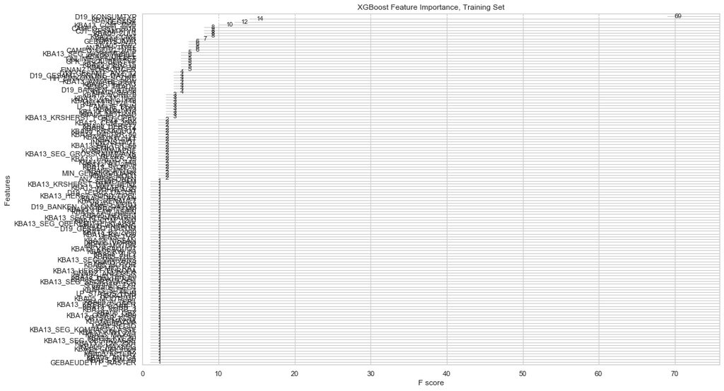

```python
ax = plot_importance(xgbc_opt)
fig = ax.figure
fig.set_size_inches(16, 10)
plt.title('XGBoost Feature Importance, Training Set')
plt.show()
```

```python
features_importance = pd.DataFrame({'value': xgbc_opt.feature_importances_},
                                   index = X_train.columns)
features_importance.sort_values(by = 'value', ascending = False, inplace = True)
display(features_importance.head(10))
```

|  | value |
| --- | --- |
| KBA13_NISSAN | 0.013948 |
| D19_KONSUMTYP | 0.012807 |
| KBA13_BJ_2009 | 0.012315 |
| KBA13_SEG_KOMPAKTKLASSE | 0.011765 |
| KBA13_VORB_1 | 0.011269 |
| KBA05_MAXAH | 0.011018 |
| KBA13_KW_121 | 0.010869 |
| KBA05_ALTER1 | 0.010800 |
| KBA05_MOD1 | 0.010703 |
| MOBI_REGIO | 0.010700 |